# PLS2 — Relación bacterias-metabolitos — Leonard et al. (2020)

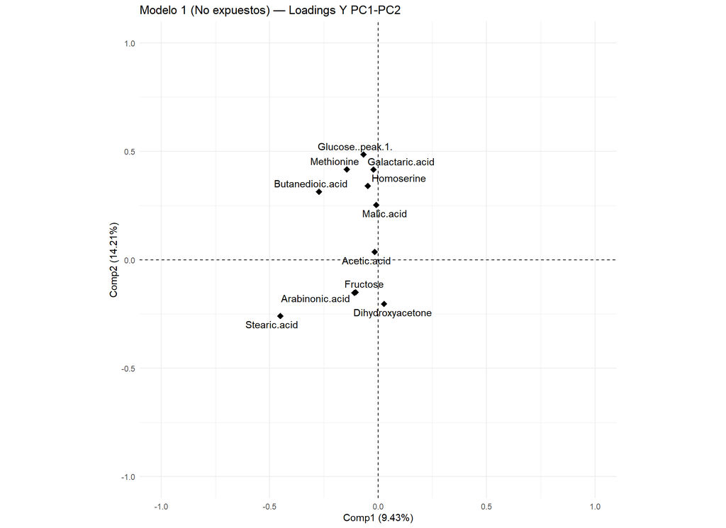

```r
plsPlot(modelo1_notexposed, type = "loadingsY", comp = 1:2, shape = "point", labels = TRUE, repel = TRUE) +
  ggtitle("Modelo 1 (No expuestos) — Loadings Y PC1-PC2")
```

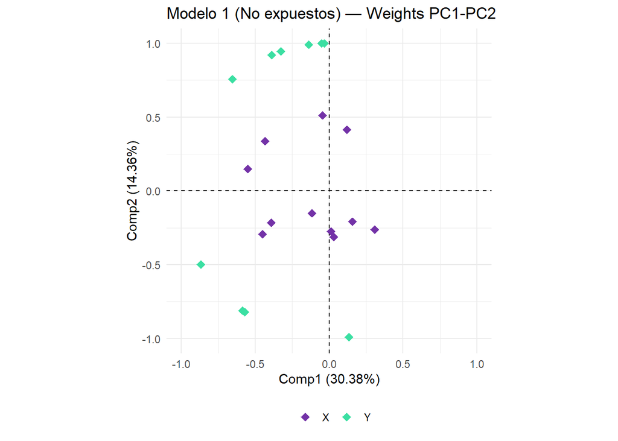

```r
plsPlot(modelo1_notexposed, type = "weights", comp = 1:2, labels = FALSE, shape = "point", repel = TRUE) +
  ggtitle("Modelo 1 (No expuestos) — Weights PC1-PC2")
```

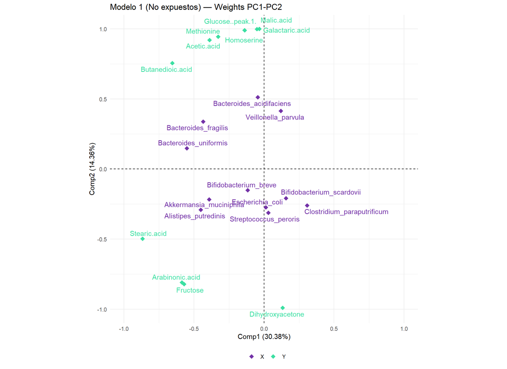

```r
plsPlot(modelo1_notexposed, type = "weights", comp = 1:2, labels = TRUE, shape = "point", repel = TRUE) +
  ggtitle("Modelo 1 (No expuestos) — Weights PC1-PC2")
```

### 1.5.4 Significación de relaciones bacteria-metabolito, por subgrupo

#### Ajuste (Jackknife / Permutación / VIP)

```r
set.seed(123)
jack_exposed <- plsVarSel(modelo1_exposed, type = "Jack", rep = 100, threshold = 0.05)
```

```r
perm_exposed <- plsVarSel(modelo1_exposed, type = "Perm", rep = 1000, threshold = 0.05)
```

```r
vip_exposed  <- plsVarSel(modelo1_exposed, type = "VIP")
```

```r
set.seed(123)
jack_notexposed <- plsVarSel(modelo1_notexposed, type = "Jack", rep = 100, threshold = 0.05)
```

```r
perm_notexposed <- plsVarSel(modelo1_notexposed, type = "Perm", rep = 1000, threshold = 0.05)
```

```r
vip_notexposed  <- plsVarSel(modelo1_notexposed, type = "VIP")
```

#### Resumen de conteos por subgrupo

```r
cat("Expuestos    - Jack:", sum(sapply(jack_exposed, nrow) > 0), " Perm:", sum(sapply(perm_exposed, nrow) > 0), " VIP:", nrow(vip_exposed), "\n")
```

```
## Expuestos    - Jack: 0  Perm: 6  VIP: 5
```

```r
cat("No expuestos - Jack:", sum(sapply(jack_notexposed, nrow) > 0), " Perm:", sum(sapply(perm_notexposed, nrow) > 0), " VIP:", nrow(vip_notexposed), "\n")
```

```
## No expuestos - Jack: 0  Perm: 4  VIP: 6
```

#### Tabla de relaciones — Expuestos

```r
tabla_exposed_model1 <- perm_exposed[sapply(perm_exposed, nrow) > 0] %>%
  imap_dfr(~ tibble(
    metabolito = .y,
    bacteria   = rownames(.x),
    p_perm     = .x$pValPerm
  )) %>%
  mutate(en_VIP = bacteria %in% rownames(vip_exposed)) %>%
  mutate(coeficiente = modelo1_exposed$coefficients[cbind(bacteria, metabolito)]) %>%
  arrange(metabolito, p_perm)

tabla_notexposed_model1 <- perm_notexposed[sapply(perm_notexposed, nrow) > 0] %>%
  imap_dfr(~ tibble(
    metabolito = .y,
    bacteria   = rownames(.x),
    p_perm     = .x$pValPerm
  )) %>%
  mutate(en_VIP = bacteria %in% rownames(vip_notexposed)) %>%
  mutate(coeficiente = modelo1_notexposed$coefficients[cbind(bacteria, metabolito)]) %>%
  arrange(metabolito, p_perm)

tabla_exposed_model1
```

```
## # A tibble: 8 × 5
##   metabolito       bacteria                p_perm en_VIP coeficiente
##   <chr>            <chr>                    <dbl> <lgl>        <dbl>
## 1 Acetic.acid      Streptococcus_peroris    0.02  TRUE        -0.299
## 2 Acetic.acid      Bacteroides_uniformis    0.04  TRUE        -0.285
## 3 Arabinonic.acid  Bacteroides_uniformis    0.049 TRUE        -0.272
## 4 Butanedioic.acid Streptococcus_peroris    0.03  TRUE        -0.275
## 5 Dihydroxyacetone Bacteroides_uniformis    0.027 TRUE        -0.319
## 6 Galactaric.acid  Bacteroides_uniformis    0.019 TRUE        -0.248
## 7 Stearic.acid     Bacteroides_uniformis    0.032 TRUE        -0.295
## 8 Stearic.acid     Akkermansia_muciniphila  0.033 TRUE         0.293
```

#### Tabla de relaciones — No expuestos

```r
tabla_notexposed_model1
```

```
## # A tibble: 7 × 5
##   metabolito       bacteria                 p_perm en_VIP coeficiente
##   <chr>            <chr>                     <dbl> <lgl>        <dbl>
## 1 Butanedioic.acid Bacteroides_uniformis     0.024 TRUE         0.196
## 2 Butanedioic.acid Bacteroides_fragilis      0.026 TRUE         0.224
## 3 Glucose..peak.1. Bacteroides_acidifaciens  0.038 TRUE         0.252
## 4 Methionine       Bacteroides_fragilis      0.043 TRUE         0.204
## 5 Stearic.acid     Bacteroides_uniformis     0.013 TRUE         0.210
## 6 Stearic.acid     Alistipes_putredinis      0.031 TRUE         0.279
## 7 Stearic.acid     Akkermansia_muciniphila   0.047 TRUE         0.233
```

```r
write_csv(tabla_exposed_model1,    file.path(processed_dir, "relaciones_bacteria_metabolito_model1_exposed.csv"))
write_csv(tabla_notexposed_model1, file.path(processed_dir, "relaciones_bacteria_metabolito_model1_notexposed.csv"))
```

### 1.5.5 Comparación Expuesto vs. No expuesto

```r
pares_exposed_model1    <- paste(tabla_exposed_model1$bacteria, tabla_exposed_model1$metabolito, sep = "__")
pares_notexposed_model1 <- paste(tabla_notexposed_model1$bacteria, tabla_notexposed_model1$metabolito, sep = "__")

cat("Relaciones solo en Expuestos:    ", length(setdiff(pares_exposed_model1, pares_notexposed_model1)), "\n")
```

```
## Relaciones solo en Expuestos:     6
```

```r
cat("Relaciones solo en No expuestos: ", length(setdiff(pares_notexposed_model1, pares_exposed_model1)), "\n")
```

```
## Relaciones solo en No expuestos:  5
```

```r
cat("Relaciones en ambos:             ", length(intersect(pares_exposed_model1, pares_notexposed_model1)), "\n")
```

```
## Relaciones en ambos:              2
```

```r
cat("\nBacterias en Expuestos:    ", paste(sort(unique(tabla_exposed_model1$bacteria)), collapse = ", "), "\n")
```

```
##
## Bacterias en Expuestos:     Akkermansia_muciniphila, Bacteroides_uniformis, Streptococcus_peroris
```

```r
cat("Bacterias en No expuestos: ", paste(sort(unique(tabla_notexposed_model1$bacteria)), collapse = ", "), "\n")
```

```
## Bacterias en No expuestos:  Akkermansia_muciniphila, Alistipes_putredinis, Bacteroides_acidifaciens, Bacteroides_fragilis, Bacteroides_uniformis
```

```r
intersect(pares_exposed_model1, pares_notexposed_model1)
```

```
## [1] "Bacteroides_uniformis__Stearic.acid"
## [2] "Akkermansia_muciniphila__Stearic.acid"
```

## 1.6 Grafos — Modelo 1

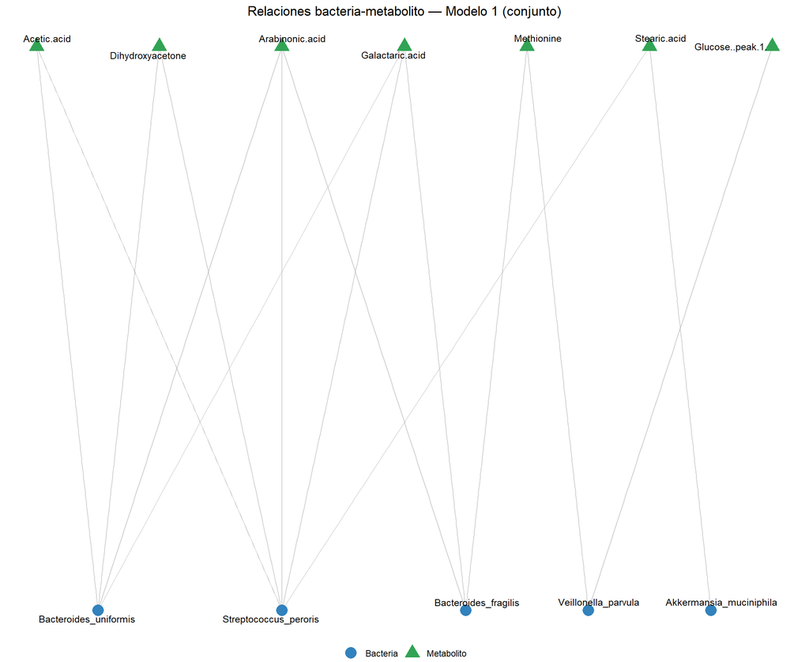

```r
plot_bipartite_graph(tabla_relaciones_model1, "Relaciones bacteria-metabolito — Modelo 1 (conjunto)")
```

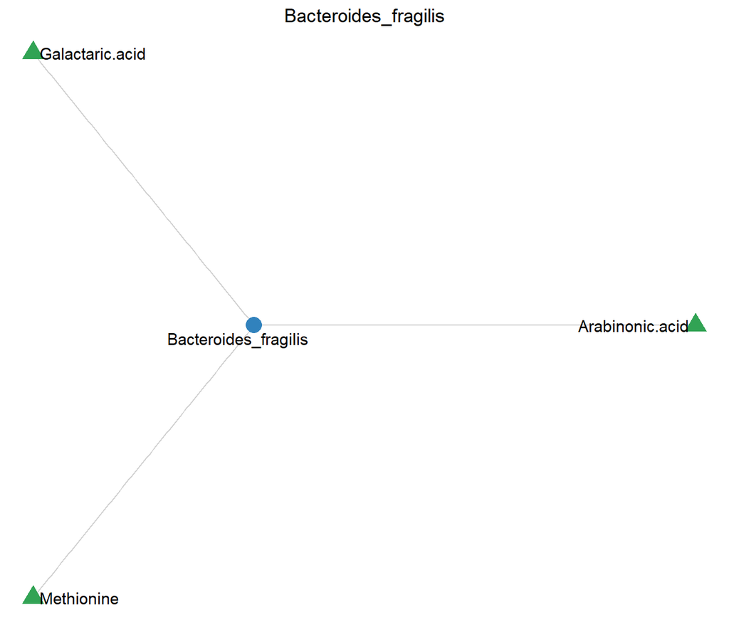

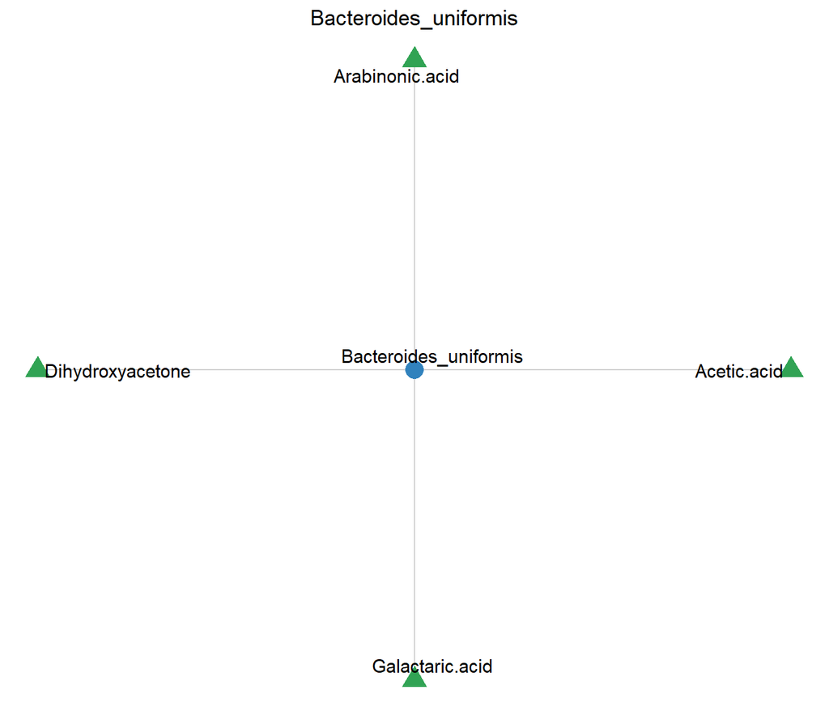

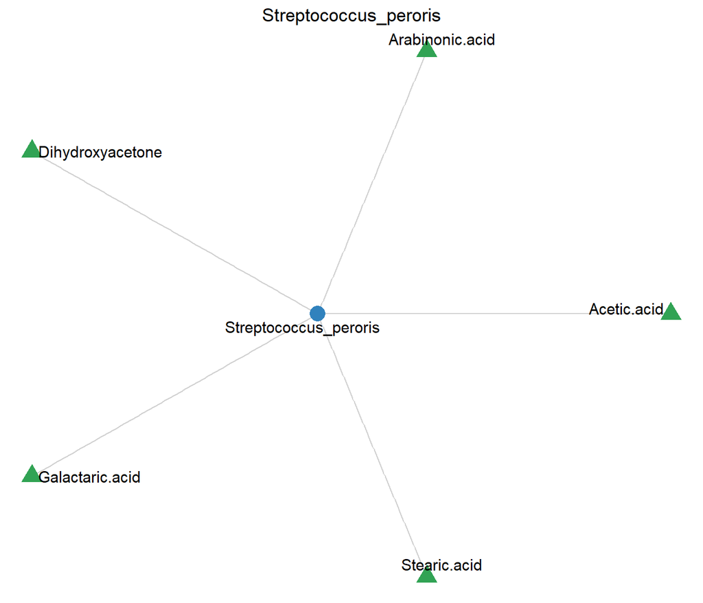

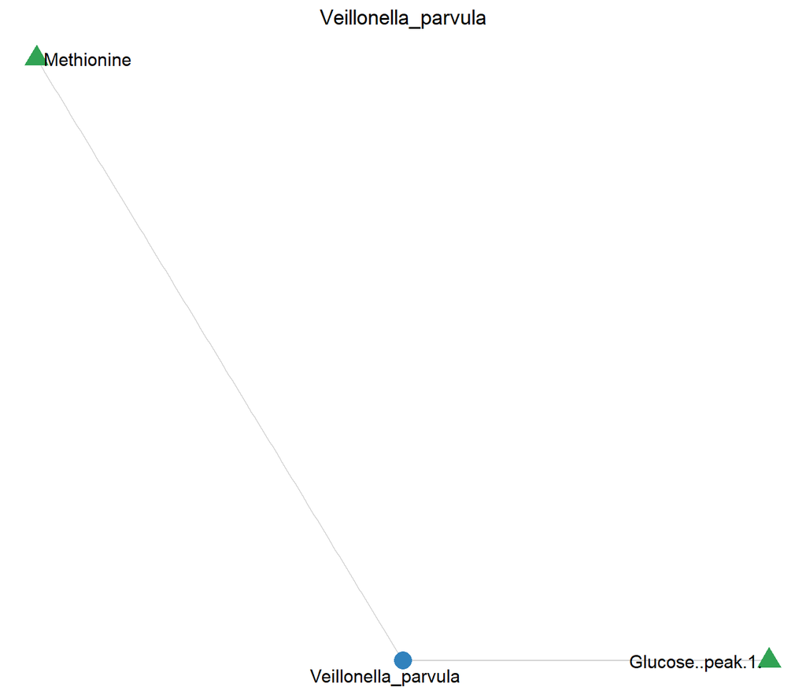

```r
walk(plot_star_by_bacteria(tabla_relaciones_model1), print)
```

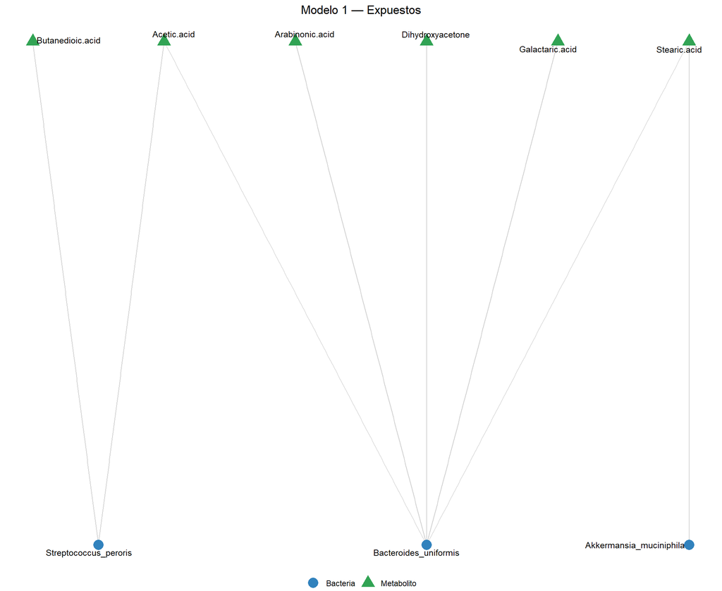

```r
plot_bipartite_graph(tabla_exposed_model1, "Modelo 1 — Expuestos")
```

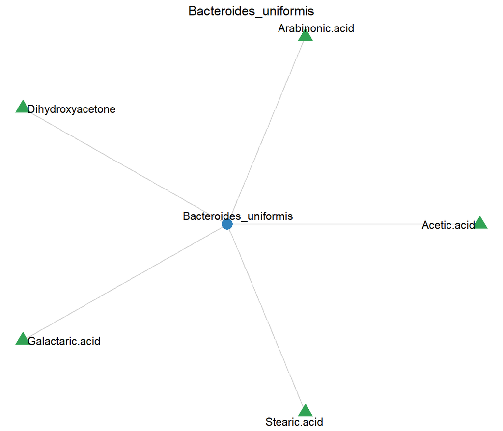

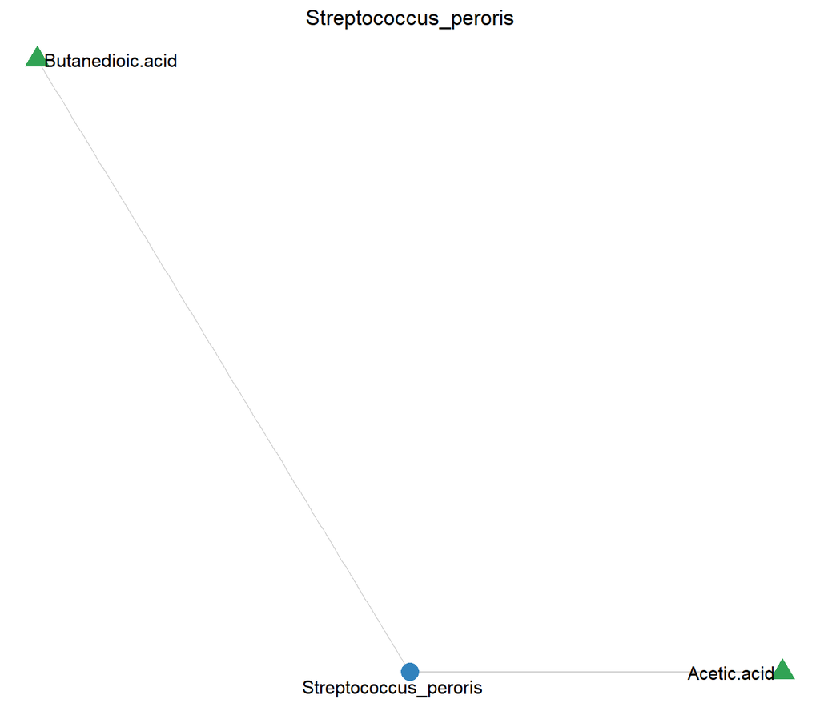

```r
walk(plot_star_by_bacteria(tabla_exposed_model1), print)
```

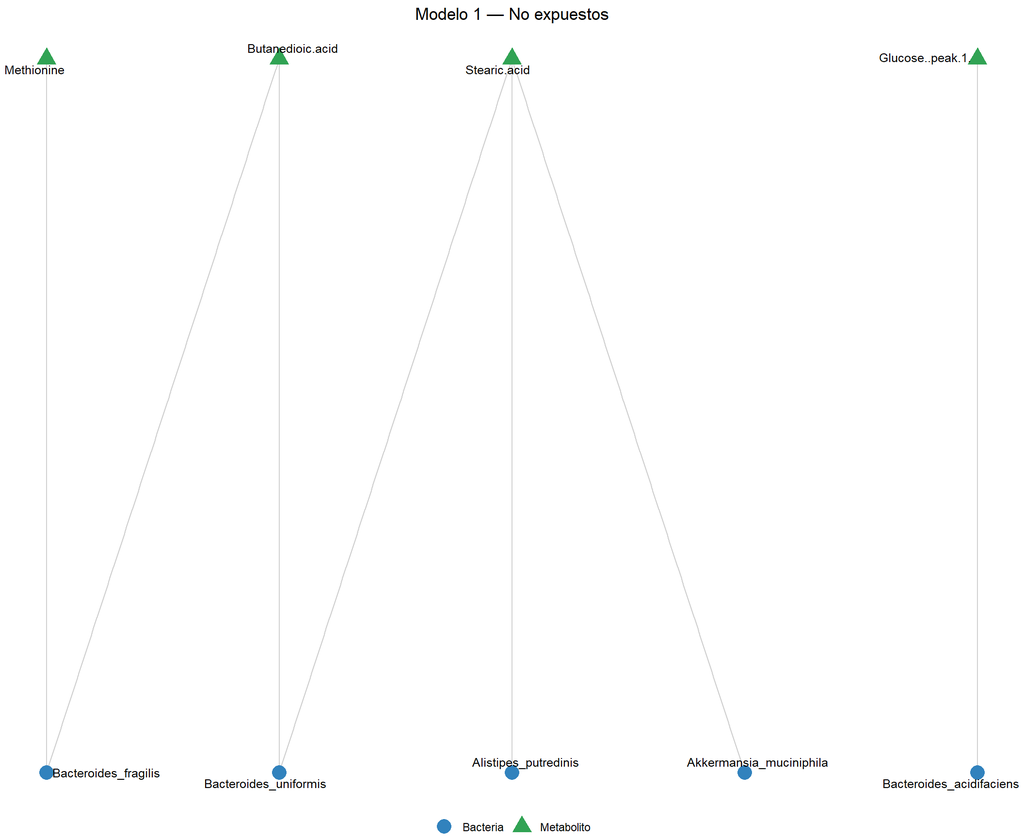

```r
plot_bipartite_graph(tabla_notexposed_model1, "Modelo 1 — No expuestos")
```

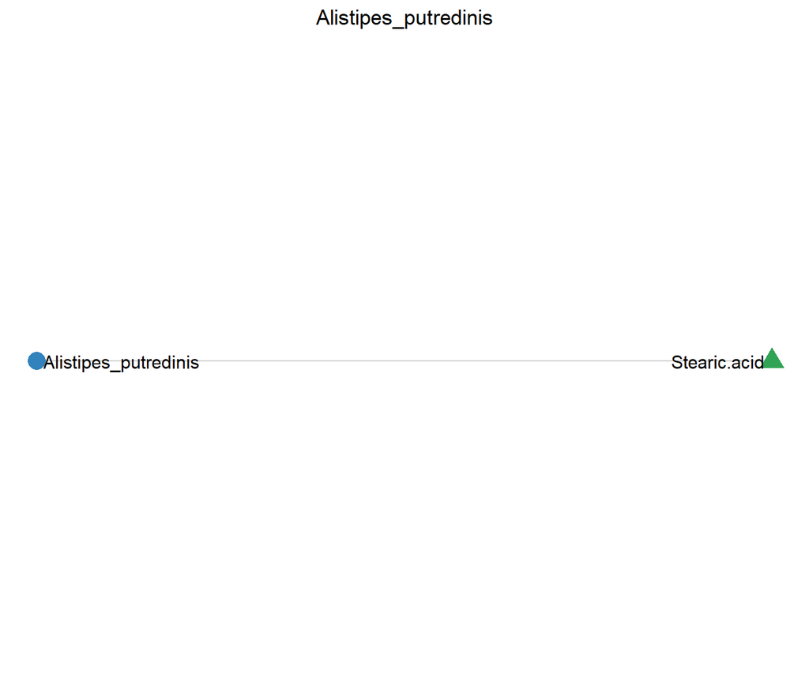

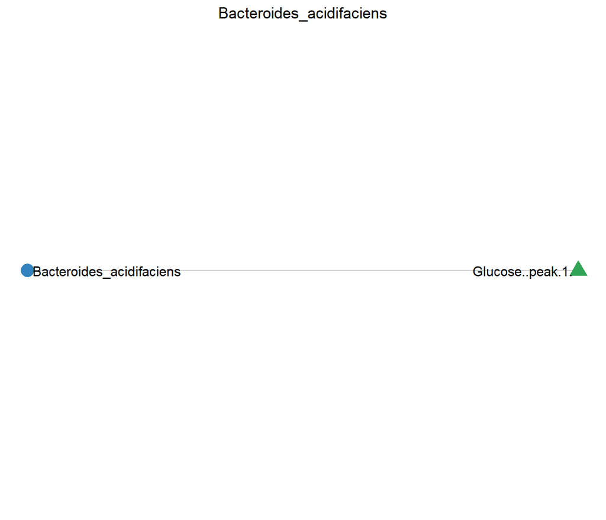

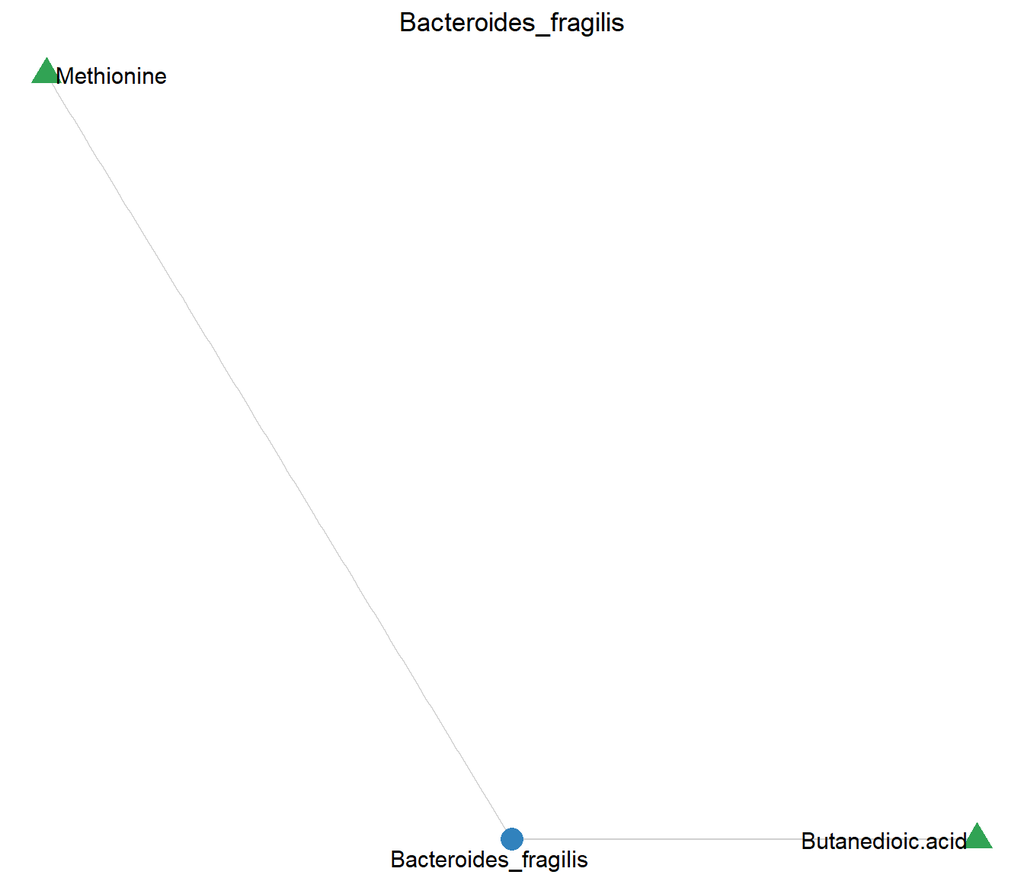

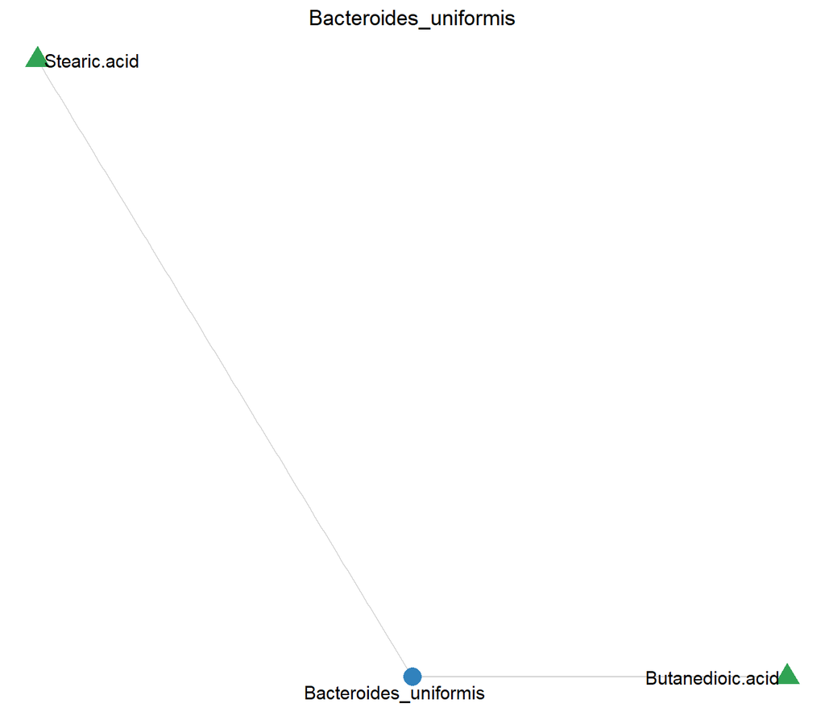

```r
walk(plot_star_by_bacteria(tabla_notexposed_model1), print)
```

## 1.7 Heatmaps — Modelo 1

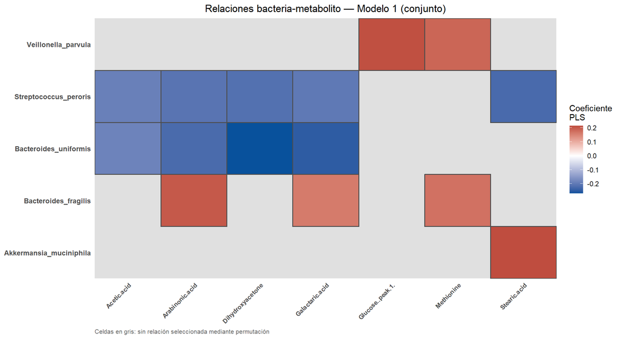

```r
plot_heatmap_relaciones(tabla_relaciones_model1, "Relaciones bacteria-metabolito — Modelo 1 (conjunto)")
```

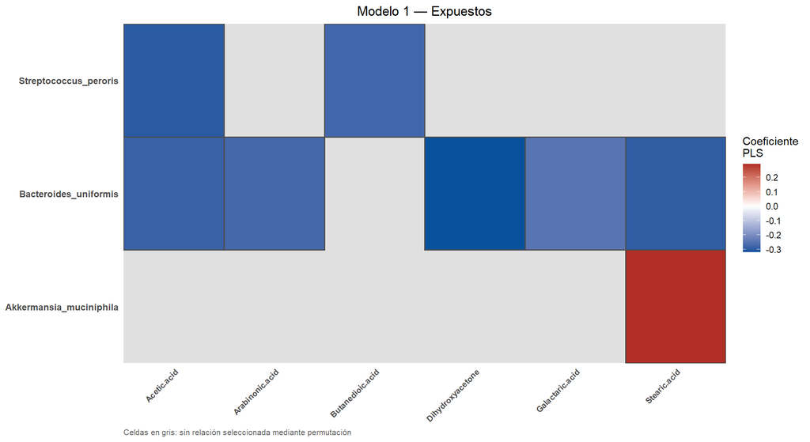

```r
plot_heatmap_relaciones(tabla_exposed_model1, "Modelo 1 — Expuestos")
```

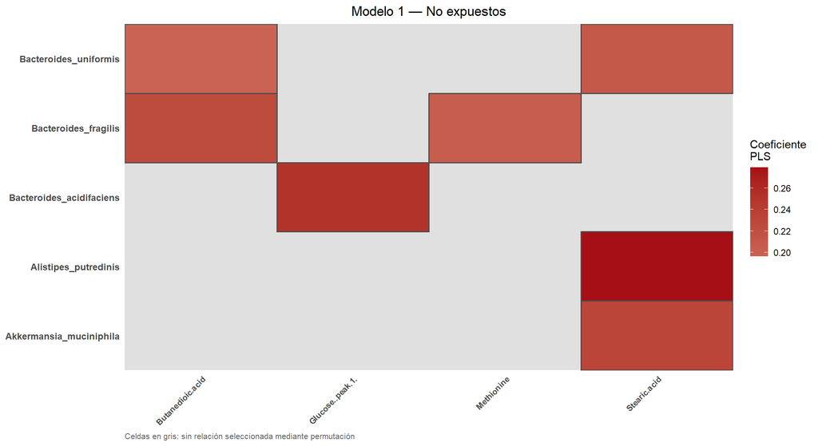

```r
plot_heatmap_relaciones(tabla_notexposed_model1, "Modelo 1 — No expuestos")
```

# MODELO 2 — Riesgo genético

## 2.1 Carga de datos y selección de variables EC-specific

```r
species_model2_lmm_results     <- readRDS(file.path(processed_dir, "species_model2_lmm_results.rds"))
metabolites_model2_lmm_results <- readRDS(file.path(processed_dir, "metabolites_model2_lmm_results.rds"))

variables_species_model2     <- species_model2_lmm_results     %>% filter(EC_specific) %>% pull(variable)
variables_metabolites_model2 <- metabolites_model2_lmm_results %>% filter(EC_specific) %>% pull(variable)

cat("Species EC-specific (Modelo 2):    ", length(variables_species_model2), "\n")
```

```
## Species EC-specific (Modelo 2):     20
```

```r
cat("Metabolitos EC-specific (Modelo 2):", length(variables_metabolites_model2), "\n")
```

```
## Metabolitos EC-specific (Modelo 2): 10
```

## 2.2 Alineación de muestras (31 sujetos)

```r
species_key_model2 <- species_clr_data %>%
  mutate(sample_key = paste(PaperID, time_point, sep = "_"))

metabolites_key_model2 <- metabolites_log_data %>%
  mutate(sample_key = paste(PaperID, time_point, sep = "_"))

common_keys_model2 <- intersect(species_key_model2$sample_key, metabolites_key_model2$sample_key)

cat("Muestras species:     ", nrow(species_key_model2), "\n")
```

```
## Muestras species:      87
```

```r
cat("Muestras metabolitos: ", nrow(metabolites_key_model2), "\n")
```

```
## Muestras metabolitos:  87
```

```r
cat("Muestras comunes:     ", length(common_keys_model2), "\n")
```

```
## Muestras comunes:      87
```

```r
species_aligned_model2     <- species_key_model2     %>% filter(sample_key %in% common_keys_model2) %>% arrange(sample_key)
metabolites_aligned_model2 <- metabolites_key_model2 %>% filter(sample_key %in% common_keys_model2) %>% arrange(sample_key)

identical(species_aligned_model2$sample_key, metabolites_aligned_model2$sample_key)
```

```
## [1] TRUE
```

```r
setdiff(species_key_model2$sample_key, metabolites_key_model2$sample_key)
```

```
## character(0)
```

```r
setdiff(metabolites_key_model2$sample_key, species_key_model2$sample_key)
```

```
## character(0)
```

## 2.3 Construcción de las matrices X (species) e Y (metabolitos)

```r
X_model2 <- species_aligned_model2     %>% select(all_of(variables_species_model2))     %>% as.data.frame()
Y_model2 <- metabolites_aligned_model2 %>% select(all_of(variables_metabolites_model2)) %>% as.data.frame()

rownames(X_model2) <- species_aligned_model2$sample_key
rownames(Y_model2) <- metabolites_aligned_model2$sample_key

cat("Filas X:", nrow(X_model2), "| Columnas X:", ncol(X_model2), "\n")
```

```
## Filas X: 87 | Columnas X: 20
```

```r
cat("Filas Y:", nrow(Y_model2), "| Columnas Y:", ncol(Y_model2), "\n")
```

```
## Filas Y: 87 | Columnas Y: 10
```

## 2.4 PLS2 — modelo conjunto (todas las muestras)

### 2.4.1 Selección del número de componentes

```r
set.seed(123)

modelo2_pls2 <- pls(
  x        = X_model2,
  y        = Y_model2,
  ncomp    = 10,
  cvFolds  = 5,
  rep      = 10,
  perm     = 100,
  scaling  = "standard",
  scalingY = "standard",
  algo     = "nipals",
  train    = 1,
  parallel = FALSE
)
```

[output not shown]

[output not shown]

```r
modelo2_pls2$summary
```

```
##    comp        R2X    cumR2X         R2Y     cumR2Y          Q2       cumQ2
## 1     1 0.14615643 0.1461564 0.030063671 0.03006367 -0.05208150 -0.05208150
## 2     2 0.11949968 0.2656561 0.030099396 0.06016307 -0.03593857 -0.08802007
## 3     3 0.08327718 0.3489333 0.032698954 0.09286202 -0.03496502 -0.12298509
## 4     4 0.07688584 0.4258191 0.020726289 0.11358831 -0.02769546 -0.15068055
## 5     5 0.07215056 0.4979697 0.014402466 0.12799078 -0.03376152 -0.18444206
## 6     6 0.06782677 0.5657965 0.013301462 0.14129224 -0.02099557 -0.20543763
## 7     7 0.06043599 0.6262324 0.012980883 0.15427312 -0.01924337 -0.22468101
## 8     8 0.03938035 0.6656128 0.011435650 0.16570877 -0.03441821 -0.25909922
## 9     9 0.04951583 0.7151286 0.006452123 0.17216089 -0.02623599 -0.28533521
## 10   10 0.03943513 0.7545637 0.006375925 0.17853682 -0.03149053 -0.31682574
##        RMSE
## 1  1.019782
## 2  1.037015
## 3  1.053531
## 4  1.066473
## 5  1.082004
## 6  1.091531
## 7  1.100202
## 8  1.115570
## 9  1.127098
## 10 1.140797
```

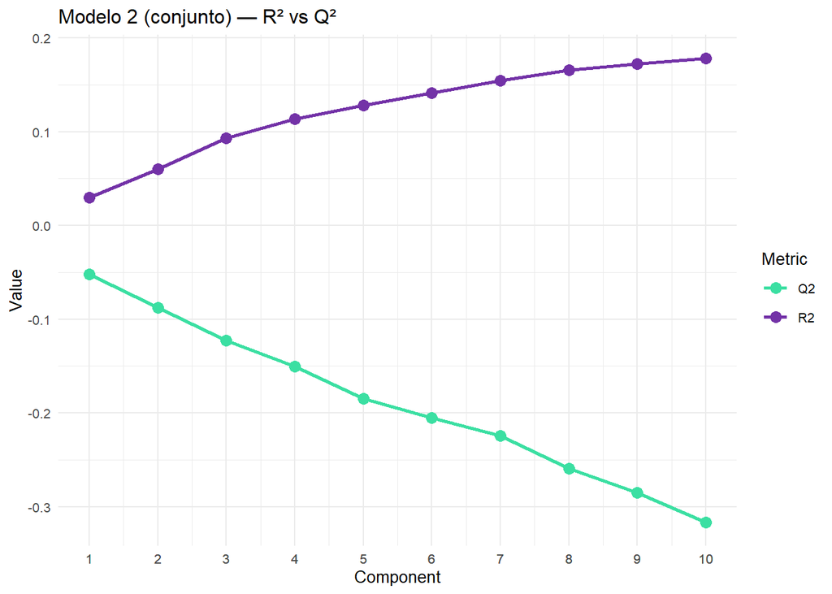

```r
plsPlot(modelo2_pls2, type = "R2vsQ2") +
  ggtitle("Modelo 2 (conjunto) — R² vs Q²")
```

```r
ncomp_model2 <- 4

set.seed(123)

modelo2_pls2 <- pls(
  x        = X_model2,
  y        = Y_model2,
  ncomp    = ncomp_model2,
  cvFolds  = 5,
  rep      = 10,
  perm     = 100,
  scaling  = "standard",
  scalingY = "standard",
  algo     = "nipals",
  train    = 1,
  parallel = FALSE
)
```

[output not shown]

[output not shown]

```r
modelo2_pls2$summary
```

```
##   comp        R2X    cumR2X        R2Y     cumR2Y          Q2       cumQ2
## 1    1 0.14615643 0.1461564 0.03006367 0.03006367 -0.05208150 -0.05208150
## 2    2 0.11949968 0.2656561 0.03009940 0.06016307 -0.03593857 -0.08802007
## 3    3 0.08327718 0.3489333 0.03269895 0.09286202 -0.03496502 -0.12298509
## 4    4 0.07688584 0.4258191 0.02072629 0.11358831 -0.02769546 -0.15068055
##       RMSE
## 1 1.019782
## 2 1.037015
## 3 1.053531
## 4 1.066473
```

### 2.4.2 Gráficos de scores

Coloreados por riesgo genético, exposición ambiental, tiempo, país, sexo y modo de parto, en comp1:2 y comp3:4 por separado.

```r
covar_risk_model2    <- data.frame(Riesgo = species_aligned_model2$Genetic_Risk_Group)
covar_exp_model2     <- data.frame(Exposicion = species_aligned_model2$Exposure_to_Environmental_Factors)
covar_time_model2    <- factor(species_aligned_model2$time_point,
                                levels = c("Enrollment", "3_months", "4_6_months"))
covar_country_model2 <- data.frame(Country = species_aligned_model2$country)
covar_gender_model2  <- data.frame(Gender = species_aligned_model2$Gender)
covar_deliv_model2   <- data.frame(Delivery = species_aligned_model2$Delivery_Mode)
```

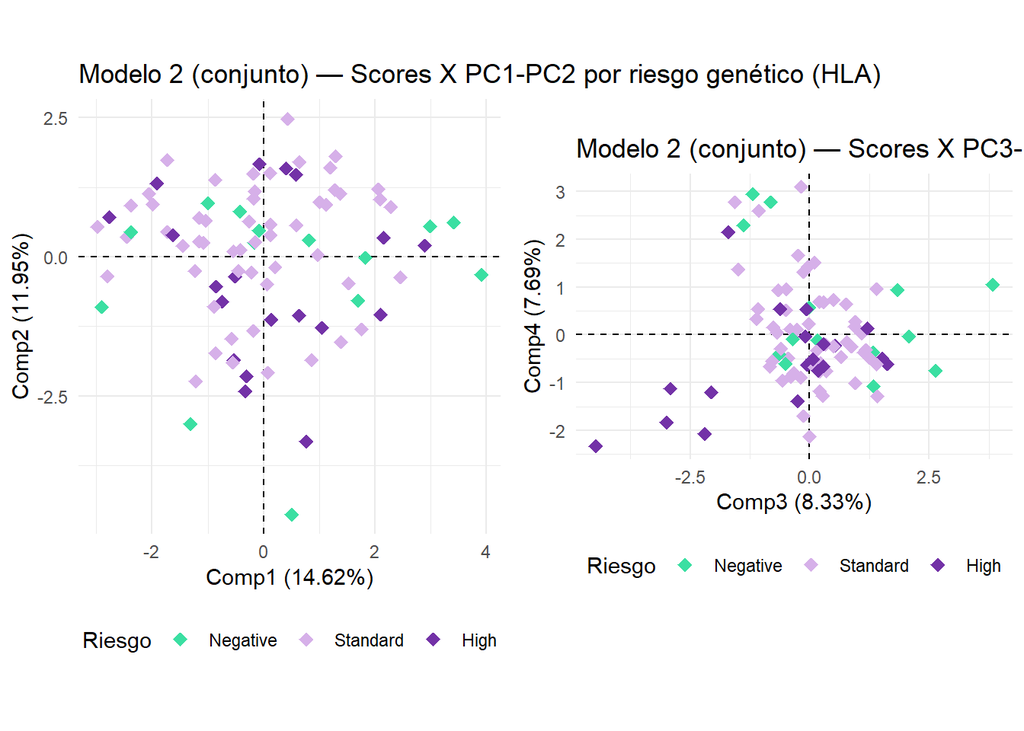

```r
p1_risk_model2  <- plsPlot(modelo2_pls2, type = "scoresX", comp = 1:2, colBy = covar_risk_model2, labels = FALSE, ellipses = FALSE) +
  ggtitle("Modelo 2 (conjunto) — Scores X PC1-PC2 por riesgo genético (HLA)")
p11_risk_model2 <- plsPlot(modelo2_pls2, type = "scoresX", comp = 3:4, colBy = covar_risk_model2, labels = FALSE, ellipses = FALSE) +
  ggtitle("Modelo 2 (conjunto) — Scores X PC3-PC4 por riesgo genético (HLA)")
grid.arrange(p1_risk_model2, p11_risk_model2, ncol = 2)
```

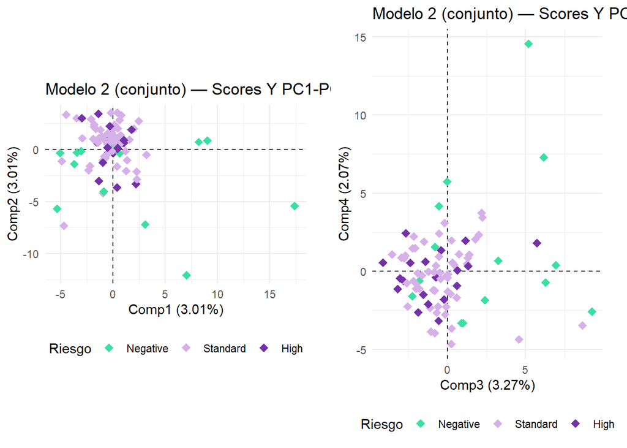

```r
p2_risk_model2  <- plsPlot(modelo2_pls2, type = "scoresY", comp = 1:2, colBy = covar_risk_model2, labels = FALSE, ellipses = FALSE) +
  ggtitle("Modelo 2 (conjunto) — Scores Y PC1-PC2 por riesgo genético (HLA)")
p21_risk_model2 <- plsPlot(modelo2_pls2, type = "scoresY", comp = 3:4, colBy = covar_risk_model2, labels = FALSE, ellipses = FALSE) +
  ggtitle("Modelo 2 (conjunto) — Scores Y PC3-PC4 por riesgo genético (HLA)")
grid.arrange(p2_risk_model2, p21_risk_model2, ncol = 2)
```

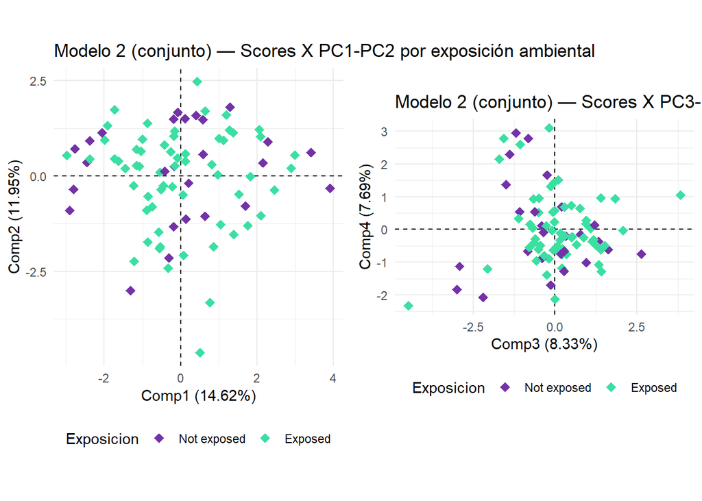

```r
p1_exp_model2  <- plsPlot(modelo2_pls2, type = "scoresX", comp = 1:2, colBy = covar_exp_model2, labels = FALSE, ellipses = FALSE) +
  ggtitle("Modelo 2 (conjunto) — Scores X PC1-PC2 por exposición ambiental")
p11_exp_model2 <- plsPlot(modelo2_pls2, type = "scoresX", comp = 3:4, colBy = covar_exp_model2, labels = FALSE, ellipses = FALSE) +
  ggtitle("Modelo 2 (conjunto) — Scores X PC3-PC4 por exposición ambiental")
grid.arrange(p1_exp_model2, p11_exp_model2, ncol = 2)
```

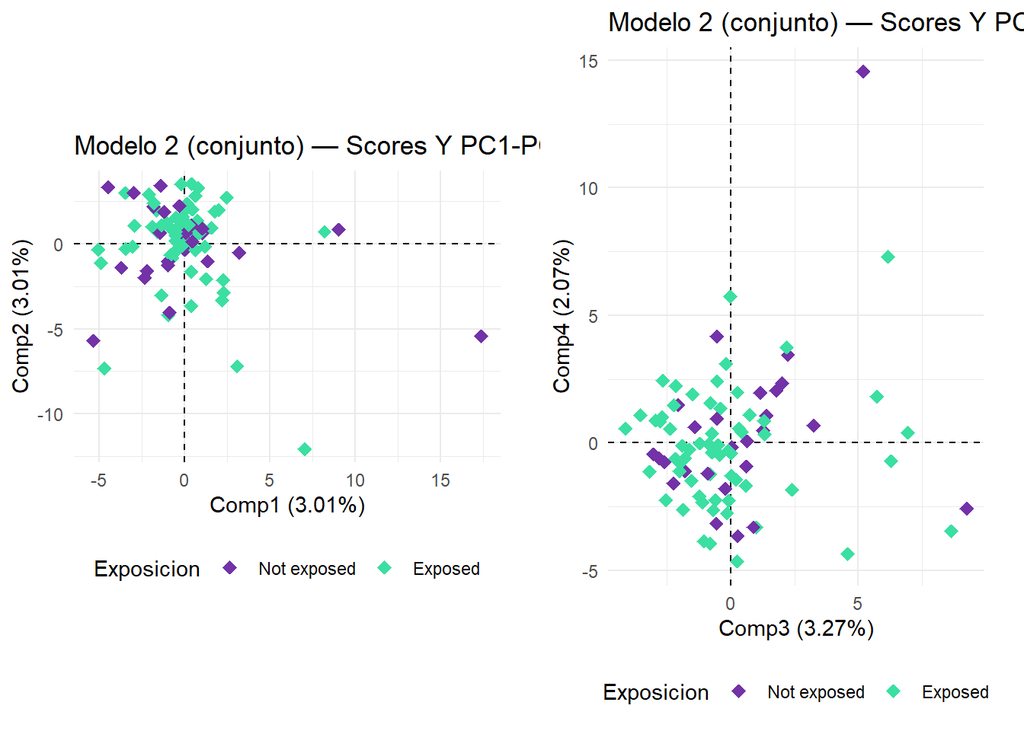

```r
p2_exp_model2  <- plsPlot(modelo2_pls2, type = "scoresY", comp = 1:2, colBy = covar_exp_model2, labels = FALSE, ellipses = FALSE) +
  ggtitle("Modelo 2 (conjunto) — Scores Y PC1-PC2 por exposición ambiental")
p21_exp_model2 <- plsPlot(modelo2_pls2, type = "scoresY", comp = 3:4, colBy = covar_exp_model2, labels = FALSE, ellipses = FALSE) +
  ggtitle("Modelo 2 (conjunto) — Scores Y PC3-PC4 por exposición ambiental")
grid.arrange(p2_exp_model2, p21_exp_model2, ncol = 2)
```

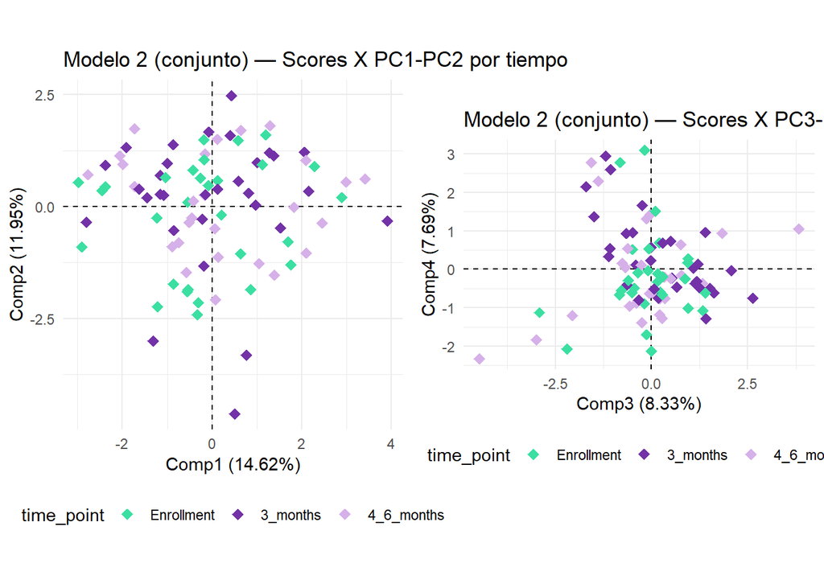

```r
p1_time_model2  <- plsPlot(modelo2_pls2, type = "scoresX", comp = 1:2,
                            colBy = data.frame(time_point = covar_time_model2), labels = FALSE, ellipses = FALSE) +
  ggtitle("Modelo 2 (conjunto) — Scores X PC1-PC2 por tiempo")
p11_time_model2 <- plsPlot(modelo2_pls2, type = "scoresX", comp = 3:4,
                            colBy = data.frame(time_point = covar_time_model2), labels = FALSE, ellipses = FALSE) +
  ggtitle("Modelo 2 (conjunto) — Scores X PC3-PC4 por tiempo")
grid.arrange(p1_time_model2, p11_time_model2, ncol = 2)
```

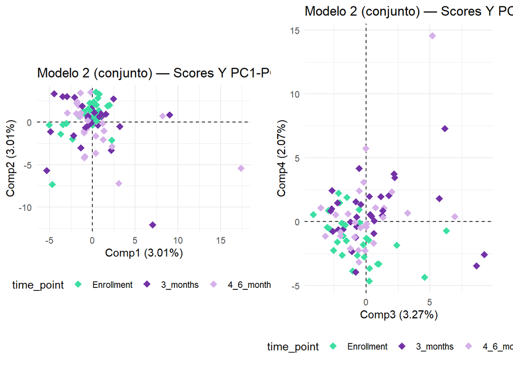

```r
p2_time_model2  <- plsPlot(modelo2_pls2, type = "scoresY", comp = 1:2,
                            colBy = data.frame(time_point = covar_time_model2), labels = FALSE, ellipses = FALSE) +
  ggtitle("Modelo 2 (conjunto) — Scores Y PC1-PC2 por tiempo")
p21_time_model2 <- plsPlot(modelo2_pls2, type = "scoresY", comp = 3:4,
                            colBy = data.frame(time_point = covar_time_model2), labels = FALSE, ellipses = FALSE) +
  ggtitle("Modelo 2 (conjunto) — Scores Y PC3-PC4 por tiempo")
grid.arrange(p2_time_model2, p21_time_model2, ncol = 2)
```

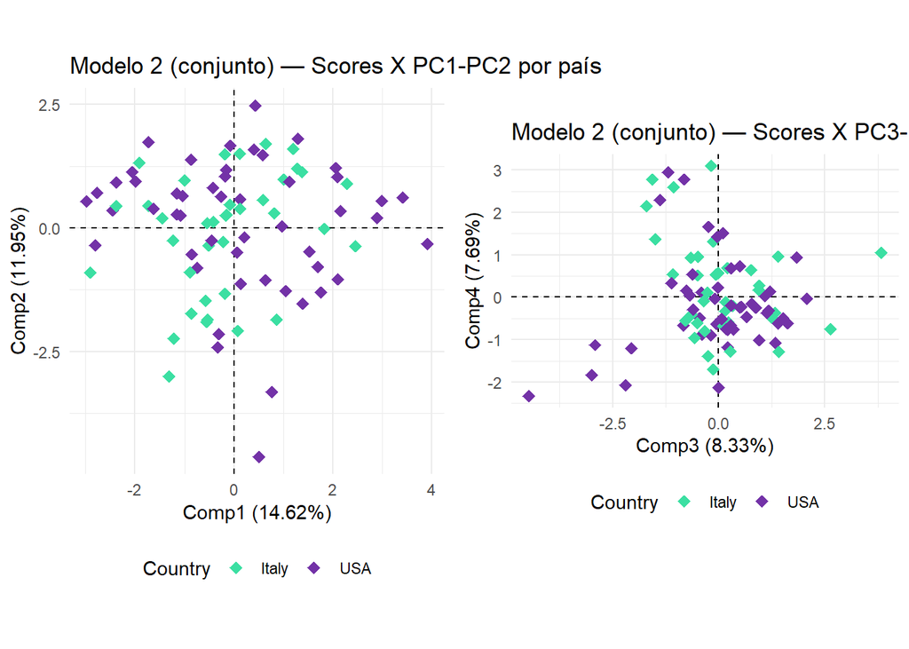

```r
p1_country_model2  <- plsPlot(modelo2_pls2, type = "scoresX", comp = 1:2, colBy = covar_country_model2, labels = FALSE, ellipses = FALSE) +
  ggtitle("Modelo 2 (conjunto) — Scores X PC1-PC2 por país")
p11_country_model2 <- plsPlot(modelo2_pls2, type = "scoresX", comp = 3:4, colBy = covar_country_model2, labels = FALSE, ellipses = FALSE) +
  ggtitle("Modelo 2 (conjunto) — Scores X PC3-PC4 por país")
grid.arrange(p1_country_model2, p11_country_model2, ncol = 2)
```

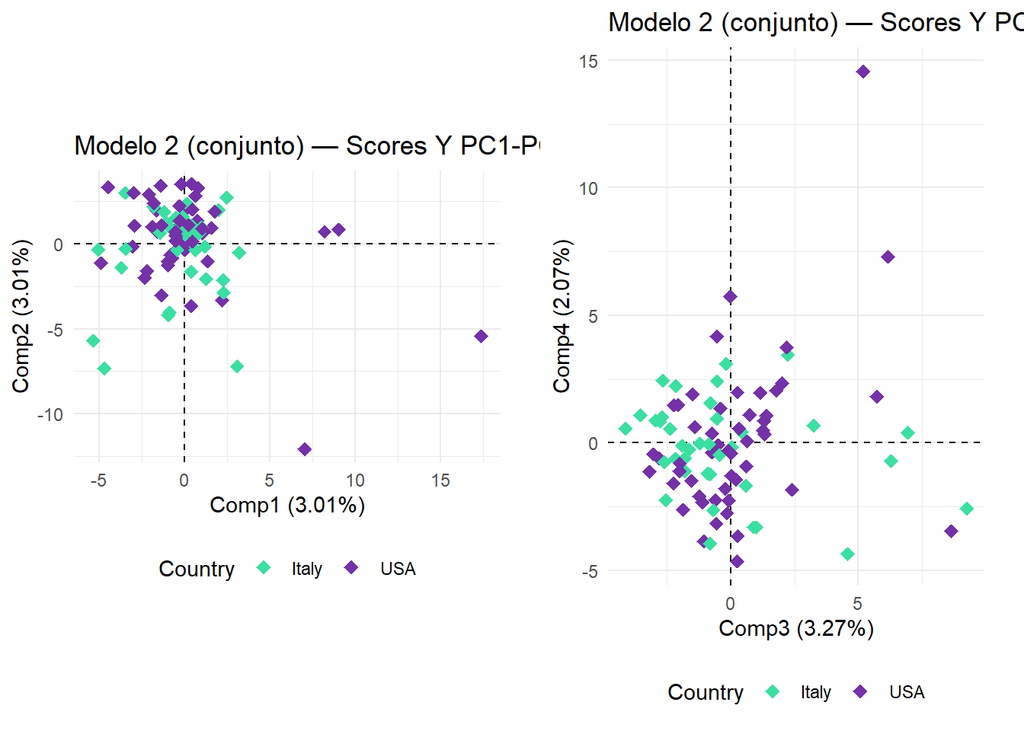

```r
p2_country_model2  <- plsPlot(modelo2_pls2, type = "scoresY", comp = 1:2, colBy = covar_country_model2, labels = FALSE, ellipses = FALSE) +
  ggtitle("Modelo 2 (conjunto) — Scores Y PC1-PC2 por país")
p21_country_model2 <- plsPlot(modelo2_pls2, type = "scoresY", comp = 3:4, colBy = covar_country_model2, labels = FALSE, ellipses = FALSE) +
  ggtitle("Modelo 2 (conjunto) — Scores Y PC3-PC4 por país")
grid.arrange(p2_country_model2, p21_country_model2, ncol = 2)
```

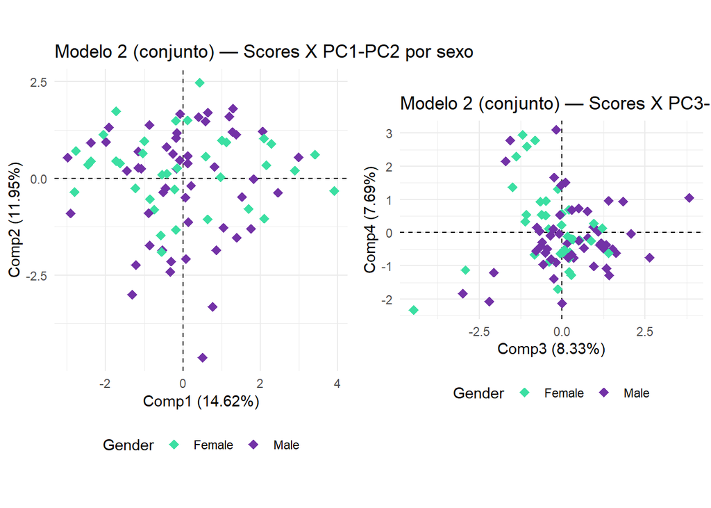

```r
p1_gender_model2  <- plsPlot(modelo2_pls2, type = "scoresX", comp = 1:2, colBy = covar_gender_model2, labels = FALSE, ellipses = FALSE) +
  ggtitle("Modelo 2 (conjunto) — Scores X PC1-PC2 por sexo")
p11_gender_model2 <- plsPlot(modelo2_pls2, type = "scoresX", comp = 3:4, colBy = covar_gender_model2, labels = FALSE, ellipses = FALSE) +
  ggtitle("Modelo 2 (conjunto) — Scores X PC3-PC4 por sexo")
grid.arrange(p1_gender_model2, p11_gender_model2, ncol = 2)
```

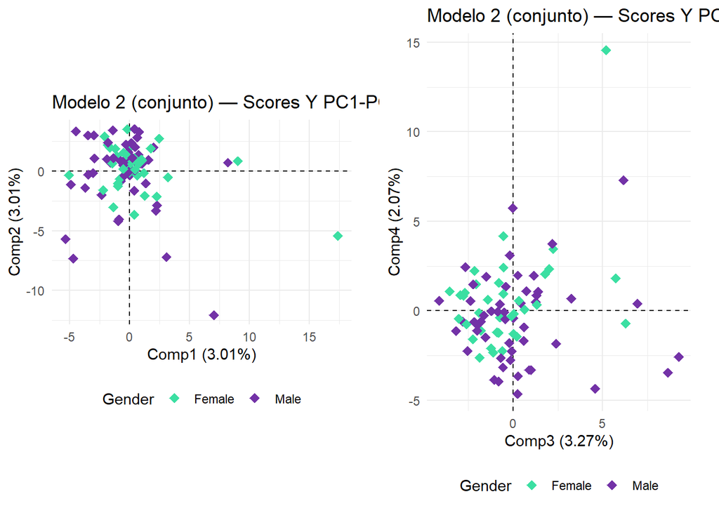

```r
p2_gender_model2  <- plsPlot(modelo2_pls2, type = "scoresY", comp = 1:2, colBy = covar_gender_model2, labels = FALSE, ellipses = FALSE) +
  ggtitle("Modelo 2 (conjunto) — Scores Y PC1-PC2 por sexo")
p21_gender_model2 <- plsPlot(modelo2_pls2, type = "scoresY", comp = 3:4, colBy = covar_gender_model2, labels = FALSE, ellipses = FALSE) +
  ggtitle("Modelo 2 (conjunto) — Scores Y PC3-PC4 por sexo")
grid.arrange(p2_gender_model2, p21_gender_model2, ncol = 2)
```

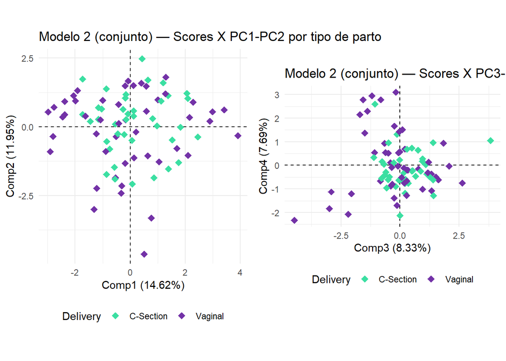

```r
p1_deliv_model2  <- plsPlot(modelo2_pls2, type = "scoresX", comp = 1:2, colBy = covar_deliv_model2, labels = FALSE, ellipses = FALSE) +
  ggtitle("Modelo 2 (conjunto) — Scores X PC1-PC2 por tipo de parto")
p11_deliv_model2 <- plsPlot(modelo2_pls2, type = "scoresX", comp = 3:4, colBy = covar_deliv_model2, labels = FALSE, ellipses = FALSE) +
  ggtitle("Modelo 2 (conjunto) — Scores X PC3-PC4 por tipo de parto")
grid.arrange(p1_deliv_model2, p11_deliv_model2, ncol = 2)
```

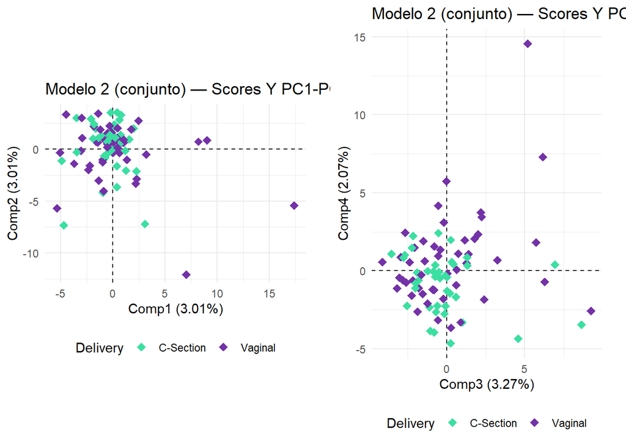

```r
p2_deliv_model2  <- plsPlot(modelo2_pls2, type = "scoresY", comp = 1:2, colBy = covar_deliv_model2, labels = FALSE, ellipses = FALSE) +
  ggtitle("Modelo 2 (conjunto) — Scores Y PC1-PC2 por tipo de parto")
p21_deliv_model2 <- plsPlot(modelo2_pls2, type = "scoresY", comp = 3:4, colBy = covar_deliv_model2, labels = FALSE, ellipses = FALSE) +
  ggtitle("Modelo 2 (conjunto) — Scores Y PC3-PC4 por tipo de parto")
grid.arrange(p2_deliv_model2, p21_deliv_model2, ncol = 2)
```

### 2.4.3 Gráficos de loadings

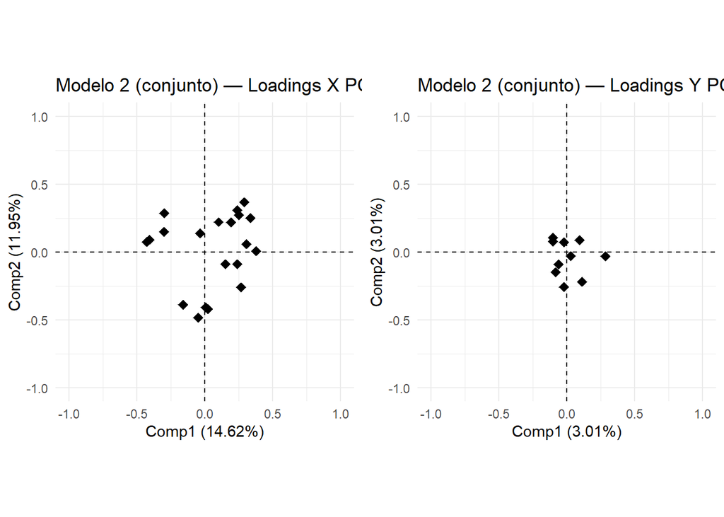

```r
p_loadX_model2 <- plsPlot(modelo2_pls2, type = "loadingsX", comp = 1:2, shape = "point", labels = FALSE, repel = TRUE) +
  ggtitle("Modelo 2 (conjunto) — Loadings X PC1-PC2")
p_loadY_model2 <- plsPlot(modelo2_pls2, type = "loadingsY", comp = 1:2, shape = "point", labels = FALSE, repel = TRUE) +
  ggtitle("Modelo 2 (conjunto) — Loadings Y PC1-PC2")
grid.arrange(p_loadX_model2, p_loadY_model2, ncol = 2)
```

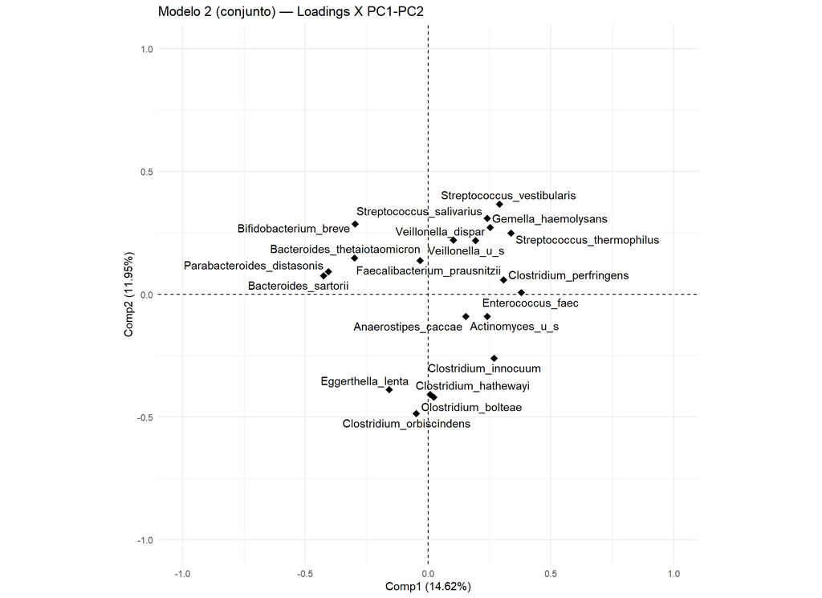

```r
plsPlot(modelo2_pls2, type = "loadingsX", comp = 1:2, shape = "point", labels = TRUE, repel = TRUE) +
  ggtitle("Modelo 2 (conjunto) — Loadings X PC1-PC2")
```

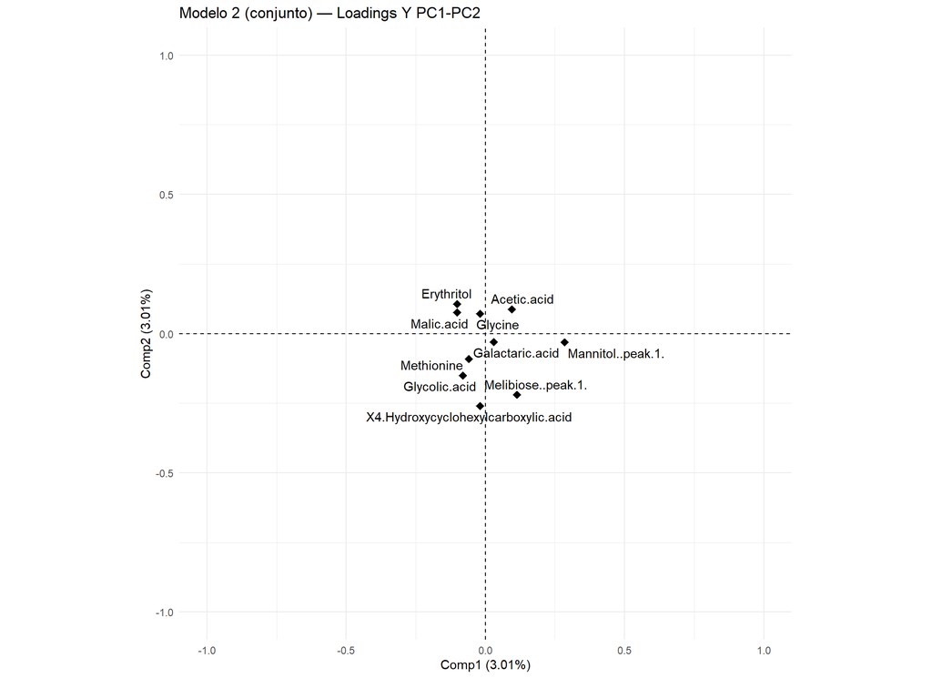

```r
plsPlot(modelo2_pls2, type = "loadingsY", comp = 1:2, shape = "point", labels = TRUE, repel = TRUE) +
  ggtitle("Modelo 2 (conjunto) — Loadings Y PC1-PC2")
```

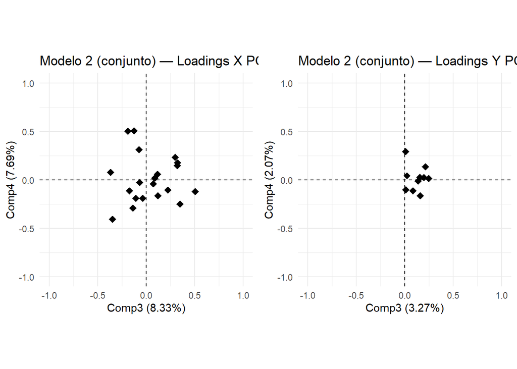

```r
p_loadX1_model2 <- plsPlot(modelo2_pls2, type = "loadingsX", comp = 3:4, shape = "point", labels = FALSE, repel = TRUE) +
  ggtitle("Modelo 2 (conjunto) — Loadings X PC3-PC4")
p_loadY1_model2 <- plsPlot(modelo2_pls2, type = "loadingsY", comp = 3:4, shape = "point", labels = FALSE, repel = TRUE) +
  ggtitle("Modelo 2 (conjunto) — Loadings Y PC3-PC4")
grid.arrange(p_loadX1_model2, p_loadY1_model2, ncol = 2)
```

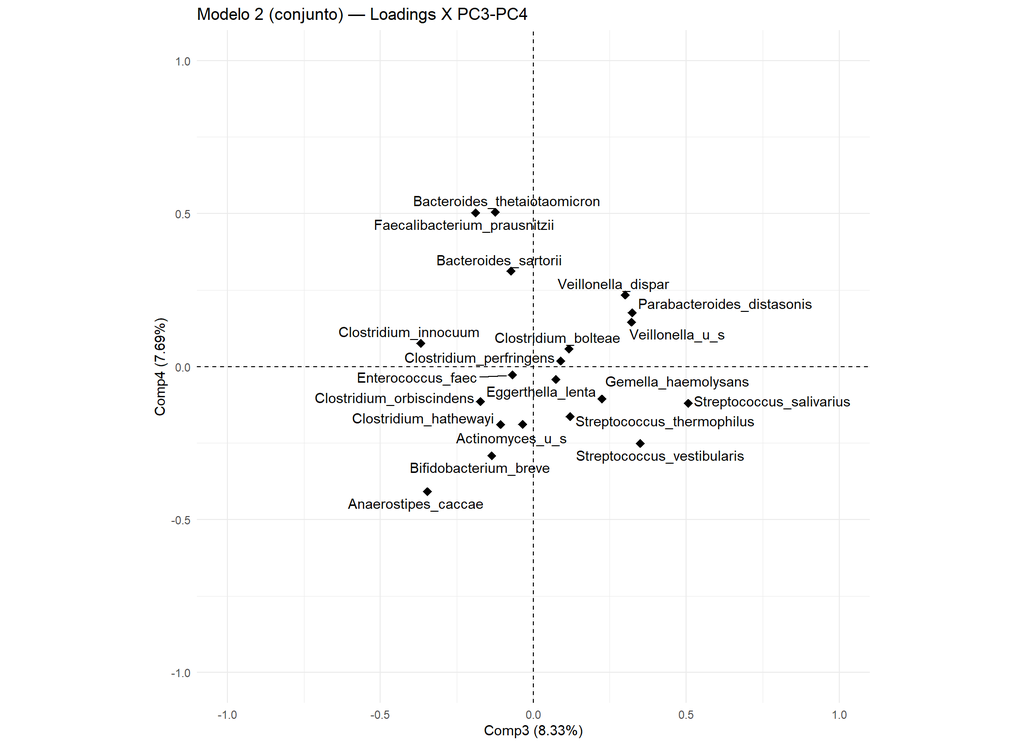

```r
plsPlot(modelo2_pls2, type = "loadingsX", comp = 3:4, shape = "point", labels = TRUE, repel = TRUE) +
  ggtitle("Modelo 2 (conjunto) — Loadings X PC3-PC4")
```

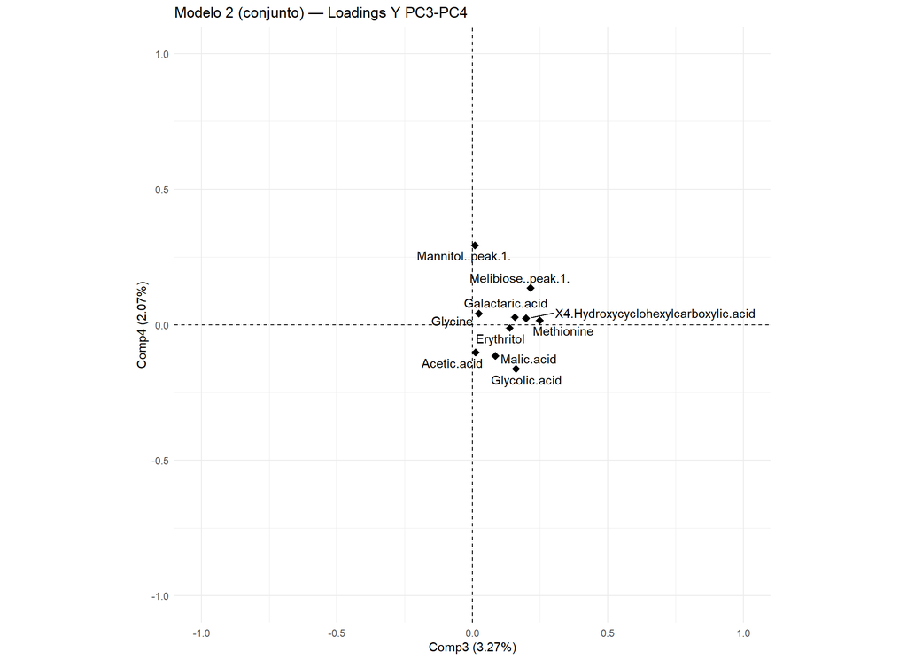

```r
plsPlot(modelo2_pls2, type = "loadingsY", comp = 3:4, shape = "point", labels = TRUE, repel = TRUE) +
  ggtitle("Modelo 2 (conjunto) — Loadings Y PC3-PC4")
```

### 2.4.4 Gráfico de weights

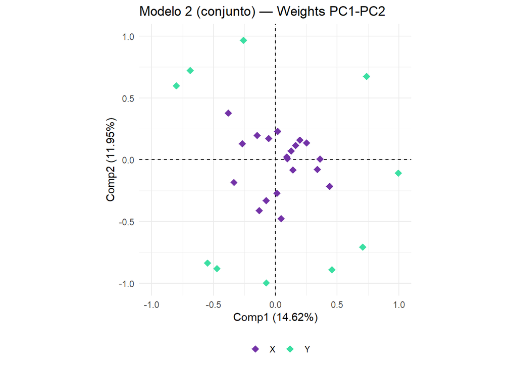

```r
plsPlot(modelo2_pls2, type = "weights", comp = 1:2, shape = "point", labels = FALSE, repel = TRUE) +
  ggtitle("Modelo 2 (conjunto) — Weights PC1-PC2")
```

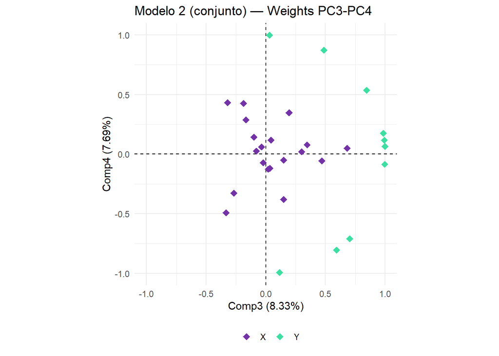

```r
plsPlot(modelo2_pls2, type = "weights", comp = 3:4, shape = "point", labels = FALSE, repel = TRUE) +
  ggtitle("Modelo 2 (conjunto) — Weights PC3-PC4")
```

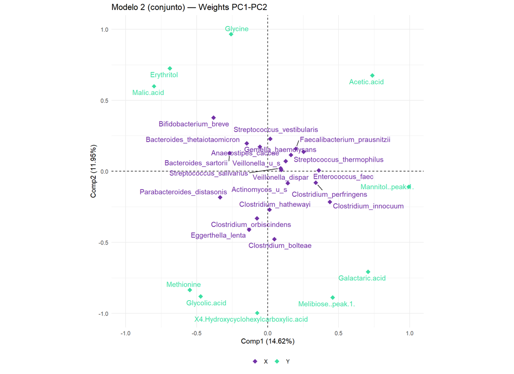

```r
plsPlot(modelo2_pls2, type = "weights", comp = 1:2, labels = TRUE, shape = "point", repel = TRUE) +
  ggtitle("Modelo 2 (conjunto) — Weights PC1-PC2")
```

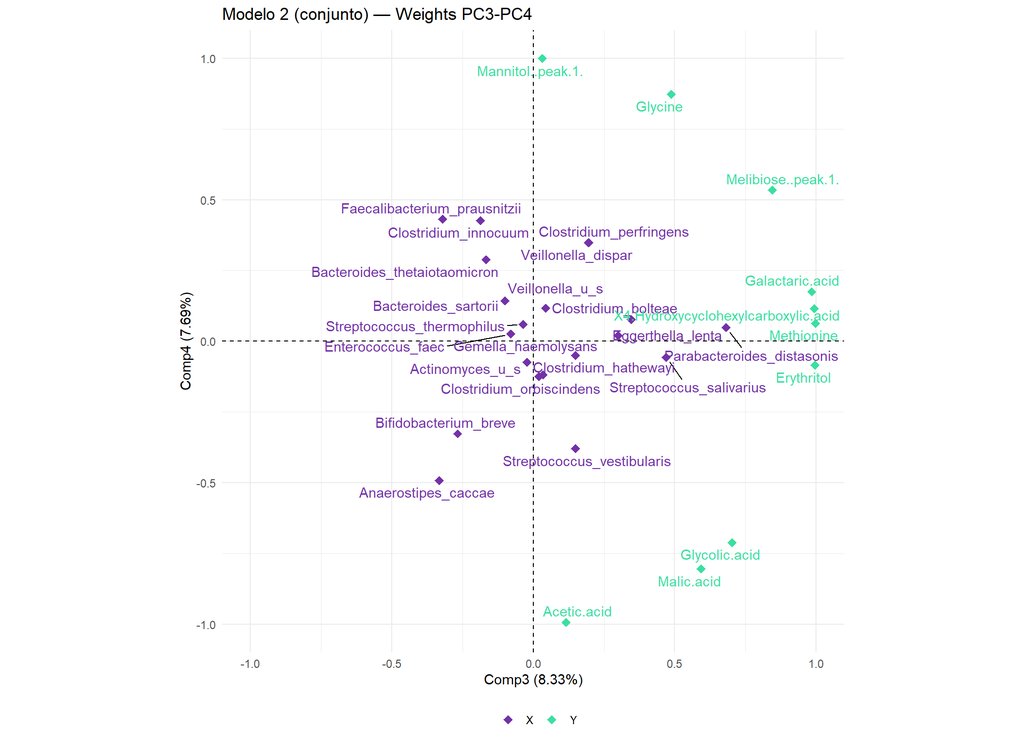

```r
plsPlot(modelo2_pls2, type = "weights", comp = 3:4, shape = "point", labels = TRUE, repel = TRUE) +
  ggtitle("Modelo 2 (conjunto) — Weights PC3-PC4")
```

### 2.4.5 Significación de las relaciones bacteria-metabolito

```r
set.seed(123)

jack_model2 <- plsVarSel(modelo2_pls2, type = "Jack", rep = 100, threshold = 0.05)
```

```r
perm_model2 <- plsVarSel(modelo2_pls2, type = "Perm", rep = 1000, threshold = 0.05)
```

```r
vip_model2  <- plsVarSel(modelo2_pls2, type = "VIP")
```

```r
cat("Metabolitos con alguna bacteria significativa (Jack):", sum(sapply(jack_model2, nrow) > 0), "\n")
```

```
## Metabolitos con alguna bacteria significativa (Jack): 0
```

```r
cat("Metabolitos con alguna bacteria significativa (Perm):", sum(sapply(perm_model2, nrow) > 0), "\n")
```

```
## Metabolitos con alguna bacteria significativa (Perm): 5
```

```r
cat("Relaciones totales (Jack):", sum(sapply(jack_model2, nrow)), "\n")
```

```
## Relaciones totales (Jack): 0
```

```r
cat("Relaciones totales (Perm):", sum(sapply(perm_model2, nrow)), "\n")
```

```
## Relaciones totales (Perm): 17
```

```r
cat("Bacterias con VIP > 1:", nrow(vip_model2), "\n")
```

```
## Bacterias con VIP > 1: 9
```

```r
bacterias_perm_model2 <- perm_model2 %>%
  discard(~ nrow(.x) == 0) %>%
  map(rownames) %>%
  unlist() %>%
  unique()

intersect(rownames(vip_model2), bacterias_perm_model2)
```

```
## [1] "Parabacteroides_distasonis"   "Clostridium_innocuum"
## [3] "Bifidobacterium_breve"        "Clostridium_bolteae"
## [5] "Anaerostipes_caccae"          "Faecalibacterium_prausnitzii"
## [7] "Eggerthella_lenta"
```

```r
perm_no_vacios_model2 <- perm_model2[sapply(perm_model2, nrow) > 0]

tabla_relaciones_model2 <- perm_no_vacios_model2 %>%
  imap_dfr(~ tibble(
    metabolito = .y,
    bacteria   = rownames(.x),
    p_perm     = .x$pValPerm
  )) %>%
  mutate(en_VIP = bacteria %in% rownames(vip_model2)) %>%
  mutate(coeficiente = modelo2_pls2$coefficients[cbind(bacteria, metabolito)]) %>%
  arrange(metabolito, p_perm)

tabla_relaciones_model2
```

```
## # A tibble: 17 × 5
##    metabolito                          bacteria        p_perm en_VIP coeficiente
##    <chr>                               <chr>            <dbl> <lgl>        <dbl>
##  1 Glycolic.acid                       Parabacteroide…  0.027 TRUE         0.156
##  2 Glycolic.acid                       Faecalibacteri…  0.038 TRUE        -0.162
##  3 Mannitol..peak.1.                   Clostridium_in…  0.003 TRUE         0.255
##  4 Mannitol..peak.1.                   Bifidobacteriu…  0.01  TRUE        -0.219
##  5 Mannitol..peak.1.                   Clostridium_pe…  0.01  FALSE        0.203
##  6 Mannitol..peak.1.                   Anaerostipes_c…  0.015 TRUE        -0.169
##  7 Mannitol..peak.1.                   Faecalibacteri…  0.027 TRUE         0.175
##  8 Mannitol..peak.1.                   Veillonella_di…  0.04  FALSE        0.131
##  9 Melibiose..peak.1.                  Anaerostipes_c…  0.002 TRUE        -0.183
## 10 Melibiose..peak.1.                  Bifidobacteriu…  0.003 TRUE        -0.228
## 11 Melibiose..peak.1.                  Clostridium_bo…  0.017 TRUE         0.195
## 12 Melibiose..peak.1.                  Parabacteroide…  0.023 TRUE         0.155
## 13 Melibiose..peak.1.                  Clostridium_pe…  0.037 FALSE        0.145
## 14 Methionine                          Parabacteroide…  0.011 TRUE         0.207
## 15 X4.Hydroxycyclohexylcarboxylic.acid Parabacteroide…  0.012 TRUE         0.190
## 16 X4.Hydroxycyclohexylcarboxylic.acid Clostridium_bo…  0.024 TRUE         0.193
## 17 X4.Hydroxycyclohexylcarboxylic.acid Eggerthella_le…  0.043 TRUE         0.169
```

```r
write_csv(tabla_relaciones_model2, file.path(processed_dir, "relaciones_bacteria_metabolito_model2_perm.csv"))
```

## 2.5 PLS2 separado por subgrupo (High vs. Standard vs. Negative)

Se incluyen los 3 niveles de riesgo genético, tratados de forma simétrica — igual que en el LMM, donde `Standard` cuenta con el mismo peso que `High` en el criterio `EC_specific` (no hay motivo para tratarlo de forma distinta aquí).

**Nota metodológica**: `High` (19 muestras) y `Negative` (14 muestras) tienen menos muestras que las 20 variables X — un escenario de alta dimensionalidad (p ≥ n). `Standard`, al tener bastantes más sujetos (19 sujetos frente a 7 y 5), previsiblemente no tiene este problema. Confirmado con la directora que el objetivo de este análisis es **descriptivo** (covariación observada en esta muestra concreta), no predictivo, por lo que se procede igualmente con los tres subgrupos; el R²Y/Q² de `High`/`Negative` no deben interpretarse como capacidad predictiva dado el tamaño muestral.

### 2.5.1 División de las muestras por subgrupo

```r
species_high_model2      <- species_aligned_model2     %>% filter(Genetic_Risk_Group == "High")
species_standard_model2  <- species_aligned_model2     %>% filter(Genetic_Risk_Group == "Standard")
species_negative_model2  <- species_aligned_model2     %>% filter(Genetic_Risk_Group == "Negative")

metabolites_high_model2     <- metabolites_aligned_model2 %>% filter(Genetic_Risk_Group == "High")
metabolites_standard_model2 <- metabolites_aligned_model2 %>% filter(Genetic_Risk_Group == "Standard")
metabolites_negative_model2 <- metabolites_aligned_model2 %>% filter(Genetic_Risk_Group == "Negative")

cat("Muestras High:     ", nrow(species_high_model2), "\n")
```

```
## Muestras High:      19
```

```r
cat("Muestras Standard: ", nrow(species_standard_model2), "\n")
```

```
## Muestras Standard:  54
```

```r
cat("Muestras Negative: ", nrow(species_negative_model2), "\n")
```

```
## Muestras Negative:  14
```

```r
identical(species_high_model2$sample_key, metabolites_high_model2$sample_key)
```

```
## [1] TRUE
```

```r
identical(species_standard_model2$sample_key, metabolites_standard_model2$sample_key)
```

```
## [1] TRUE
```

```r
identical(species_negative_model2$sample_key, metabolites_negative_model2$sample_key)
```

```
## [1] TRUE
```

```r
X_high_model2 <- species_high_model2 %>% select(all_of(variables_species_model2)) %>% as.data.frame()
Y_high_model2 <- metabolites_high_model2 %>% select(all_of(variables_metabolites_model2)) %>% as.data.frame()
rownames(X_high_model2) <- species_high_model2$sample_key
rownames(Y_high_model2) <- metabolites_high_model2$sample_key

X_standard_model2 <- species_standard_model2 %>% select(all_of(variables_species_model2)) %>% as.data.frame()
Y_standard_model2 <- metabolites_standard_model2 %>% select(all_of(variables_metabolites_model2)) %>% as.data.frame()
rownames(X_standard_model2) <- species_standard_model2$sample_key
rownames(Y_standard_model2) <- metabolites_standard_model2$sample_key

X_negative_model2 <- species_negative_model2 %>% select(all_of(variables_species_model2)) %>% as.data.frame()
Y_negative_model2 <- metabolites_negative_model2 %>% select(all_of(variables_metabolites_model2)) %>% as.data.frame()
rownames(X_negative_model2) <- species_negative_model2$sample_key
rownames(Y_negative_model2) <- metabolites_negative_model2$sample_key

cat("High:     X", dim(X_high_model2), " Y", dim(Y_high_model2), "\n")
```

```
## High:     X 19 20  Y 19 10
```

```r
cat("Standard: X", dim(X_standard_model2), " Y", dim(Y_standard_model2), "\n")
```

```
## Standard: X 54 20  Y 54 10
```

```r
cat("Negative: X", dim(X_negative_model2), " Y", dim(Y_negative_model2), "\n")
```

```
## Negative: X 14 20  Y 14 10
```

### 2.5.2 Selección del número de componentes (por subgrupo)

Con `High`/`Negative` en p ≥ n, se usa `cvFolds = 3` para ambos. Para `Standard`, al tener previsiblemente más muestras que variables, se usa `cvFolds = 5` (igual que en el modelo conjunto) — comprobar con el `dim()` anterior si esto es razonable.

#### Ajuste exploratorio (ncomp = 10)

```r
set.seed(123)
modelo2_high <- pls(
  x = X_high_model2, y = Y_high_model2, ncomp = 10,
  cvFolds = 3, rep = 10, perm = 100,
  scaling = "standard", scalingY = "standard",
  algo = "nipals", train = 1, parallel = FALSE
)
```

[output not shown]

[output not shown]

```r
set.seed(123)
modelo2_standard <- pls(
  x = X_standard_model2, y = Y_standard_model2, ncomp = 10,
  cvFolds = 5, rep = 10, perm = 100,
  scaling = "standard", scalingY = "standard",
  algo = "nipals", train = 1, parallel = FALSE
)
```

[output not shown]

```r
set.seed(123)
modelo2_negative <- pls(
  x = X_negative_model2, y = Y_negative_model2, ncomp = 10,
  cvFolds = 3, rep = 10, perm = 100,
  scaling = "standard", scalingY = "standard",
  algo = "nipals", train = 1, parallel = FALSE
)
```

[output not shown]

#### High

```r
modelo2_high$summary
```

```
##    comp        R2X    cumR2X        R2Y    cumR2Y         Q2      cumQ2
## 1     1 0.24776529 0.2477653 0.12018932 0.1201893 -0.1514400 -0.1514400
## 2     2 0.17218444 0.4199497 0.08927857 0.2094679 -0.1810083 -0.3324483
## 3     3 0.09453362 0.5144834 0.10085141 0.3103193 -0.1532798 -0.4857281
## 4     4 0.10999556 0.6244789 0.08131672 0.3916360 -0.1691713 -0.6548994
## 5     5 0.10081167 0.7252906 0.06524064 0.4568767 -0.2770162 -0.9319156
## 6     6 0.04700600 0.7722966 0.08622107 0.5430977 -0.2458007 -1.1777162
## 7     7 0.05213567 0.8244323 0.05455379 0.5976515 -0.2133456 -1.3910618
## 8     8 0.04618474 0.8706170 0.04521345 0.6428650 -0.4322984 -1.8233603
## 9     9 0.03433590 0.9049529 0.04618956 0.6890545 -0.2973137 -2.1206740
## 10   10 0.02381452 0.9287674 0.05371313 0.7427676 -0.4911074 -2.6117814
##        RMSE
## 1  1.044005
## 2  1.122951
## 3  1.185044
## 4  1.250297
## 5  1.348831
## 6  1.432351
## 7  1.501181
## 8  1.630518
## 9  1.714584
## 10 1.843477
```

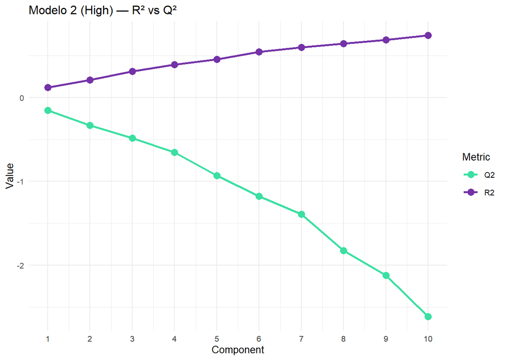

```r
plsPlot(modelo2_high, type = "R2vsQ2") +
  ggtitle("Modelo 2 (High) — R² vs Q²")
```

#### Standard

```r
modelo2_standard$summary
```

```
##    comp        R2X    cumR2X        R2Y     cumR2Y          Q2      cumQ2
## 1     1 0.11879092 0.1187909 0.04045181 0.04045181 -0.10103632 -0.1010363
## 2     2 0.13330360 0.2520945 0.03449666 0.07494847 -0.05597174 -0.1570081
## 3     3 0.11177052 0.3638650 0.03529850 0.11024697 -0.04307935 -0.2000874
## 4     4 0.07722968 0.4410947 0.04182443 0.15207141 -0.03370934 -0.2337968
## 5     5 0.06515504 0.5062498 0.02982371 0.18189512 -0.04657306 -0.2803698
## 6     6 0.07380386 0.5800536 0.01851963 0.20041476 -0.05615704 -0.3365269
## 7     7 0.05196734 0.6320210 0.02211139 0.22252614 -0.07276027 -0.4092871
## 8     8 0.06795689 0.6999779 0.01624271 0.23876885 -0.05584615 -0.4651333
## 9     9 0.03942938 0.7394072 0.02049321 0.25926207 -0.05060851 -0.5157418
## 10   10 0.03060096 0.7700082 0.02080565 0.28006772 -0.04913436 -0.5648761
##        RMSE
## 1  1.039486
## 2  1.065586
## 3  1.085259
## 4  1.100353
## 5  1.120942
## 6  1.145263
## 7  1.175980
## 8  1.199063
## 9  1.219624
## 10 1.239238
```

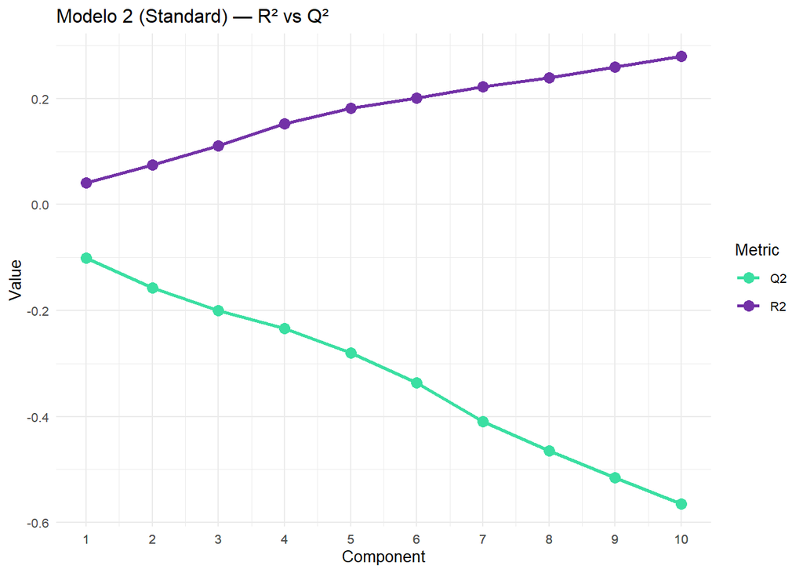

```r
plsPlot(modelo2_standard, type = "R2vsQ2") +
  ggtitle("Modelo 2 (Standard) — R² vs Q²")
```

#### Negative

```r
modelo2_negative$summary
```

```
##    comp        R2X    cumR2X        R2Y    cumR2Y         Q2      cumQ2
## 1     1 0.23763079 0.2376308 0.25453421 0.2545342 -0.1181579 -0.1181579
## 2     2 0.14502619 0.3826570 0.15916939 0.4137036 -0.2990649 -0.4172229
## 3     3 0.11556388 0.4982209 0.09997090 0.5136745 -0.1862562 -0.6034790
## 4     4 0.16031987 0.6585407 0.05802061 0.5716951 -0.2505200 -0.8539990
## 5     5 0.09926436 0.7578051 0.05489069 0.6265858 -0.1322895 -0.9862885
## 6     6 0.02812246 0.7859276 0.10298973 0.7295755 -0.3016679 -1.2879564
## 7     7 0.06146548 0.8473930 0.03151718 0.7610927 -0.2221226 -1.5100790
## 8     8 0.06188717 0.9092802 0.02547043 0.7865631 -0.3259387 -1.8360177
## 9     9 0.02668536 0.9359656 0.03535817 0.8219213 -0.4872524 -2.3232701
## 10   10 0.04977581 0.9857414 0.01602709 0.8379484 -0.3850146 -2.7082847
##        RMSE
## 1  1.016520
## 2  1.139869
## 3  1.211285
## 4  1.298196
## 5  1.345481
## 6  1.450247
## 7  1.516806
## 8  1.608909
## 9  1.735266
## 10 1.819508
```

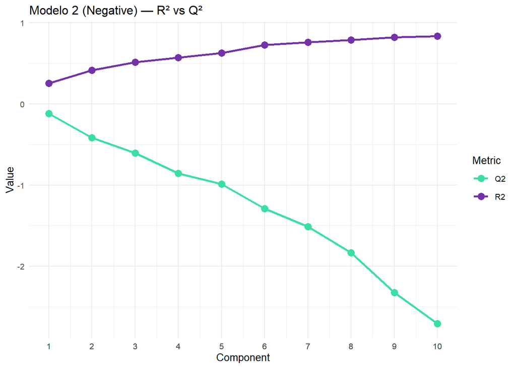

```r
plsPlot(modelo2_negative, type = "R2vsQ2") +
  ggtitle("Modelo 2 (Negative) — R² vs Q²")
```

#### Reajuste con el nº de componentes definitivo

```r
ncomp_model2_high     <- 2
ncomp_model2_standard <- 4
ncomp_model2_negative <- 2

set.seed(123)
modelo2_high <- pls(
  x = X_high_model2, y = Y_high_model2, ncomp = ncomp_model2_high,
  cvFolds = 3, rep = 10, perm = 100,
  scaling = "standard", scalingY = "standard",
  algo = "nipals", train = 1, parallel = FALSE
)
```

```
##
##  Running optimization:
##
##  Running optimization:
##
##  Running optimization:
```

[output not shown]

```r
set.seed(123)
modelo2_standard <- pls(
  x = X_standard_model2, y = Y_standard_model2, ncomp = ncomp_model2_standard,
  cvFolds = 5, rep = 10, perm = 100,
  scaling = "standard", scalingY = "standard",
  algo = "nipals", train = 1, parallel = FALSE
)
```

[output not shown]

```r
set.seed(123)
modelo2_negative <- pls(
  x = X_negative_model2, y = Y_negative_model2, ncomp = ncomp_model2_negative,
  cvFolds = 3, rep = 10, perm = 100,
  scaling = "standard", scalingY = "standard",
  algo = "nipals", train = 1, parallel = FALSE
)
```

[output not shown]

**High** (`ncomp = 2`)

```r
modelo2_high$summary
```

```
##   comp       R2X    cumR2X        R2Y    cumR2Y         Q2      cumQ2     RMSE
## 1    1 0.2477653 0.2477653 0.12018932 0.1201893 -0.1514400 -0.1514400 1.044005
## 2    2 0.1721844 0.4199497 0.08927857 0.2094679 -0.1810083 -0.3324483 1.122951
```

**Standard** (`ncomp = 4`)

```r
modelo2_standard$summary
```

```
##   comp        R2X    cumR2X        R2Y     cumR2Y          Q2      cumQ2
## 1    1 0.11879092 0.1187909 0.04045181 0.04045181 -0.10103632 -0.1010363
## 2    2 0.13330360 0.2520945 0.03449666 0.07494847 -0.05597174 -0.1570081
## 3    3 0.11177052 0.3638650 0.03529850 0.11024697 -0.04307935 -0.2000874
## 4    4 0.07722968 0.4410947 0.04182443 0.15207141 -0.03370934 -0.2337968
##       RMSE
## 1 1.039486
## 2 1.065586
## 3 1.085259
## 4 1.100353
```

**Negative** (`ncomp = 2`)

```r
modelo2_negative$summary
```

```
##   comp       R2X    cumR2X       R2Y    cumR2Y         Q2      cumQ2     RMSE
## 1    1 0.2376308 0.2376308 0.2545342 0.2545342 -0.1181579 -0.1181579 1.016520
## 2    2 0.1450262 0.3826570 0.1591694 0.4137036 -0.2990649 -0.4172229 1.139869
```

### 2.5.3 Gráficos exploratorios por subgrupo

#### High

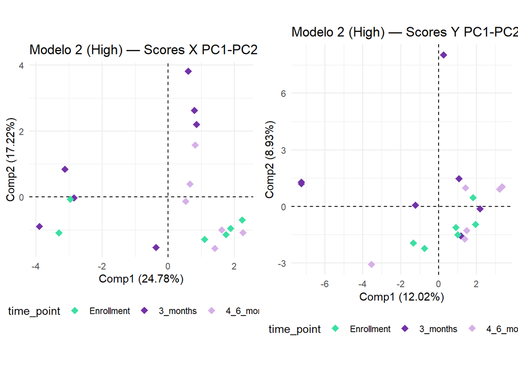

```r
covar_time_high_model2 <- factor(species_high_model2$time_point,
                                  levels = c("Enrollment", "3_months", "4_6_months"))

p1_high <- plsPlot(modelo2_high, type = "scoresX", comp = 1:2,
                    colBy = data.frame(time_point = covar_time_high_model2),
                    labels = FALSE, ellipses = FALSE) +
  ggtitle("Modelo 2 (High) — Scores X PC1-PC2 por tiempo")

p2_high <- plsPlot(modelo2_high, type = "scoresY", comp = 1:2,
                    colBy = data.frame(time_point = covar_time_high_model2),
                    labels = FALSE, ellipses = FALSE) +
  ggtitle("Modelo 2 (High) — Scores Y PC1-PC2 por tiempo")

grid.arrange(p1_high, p2_high, ncol = 2)
```

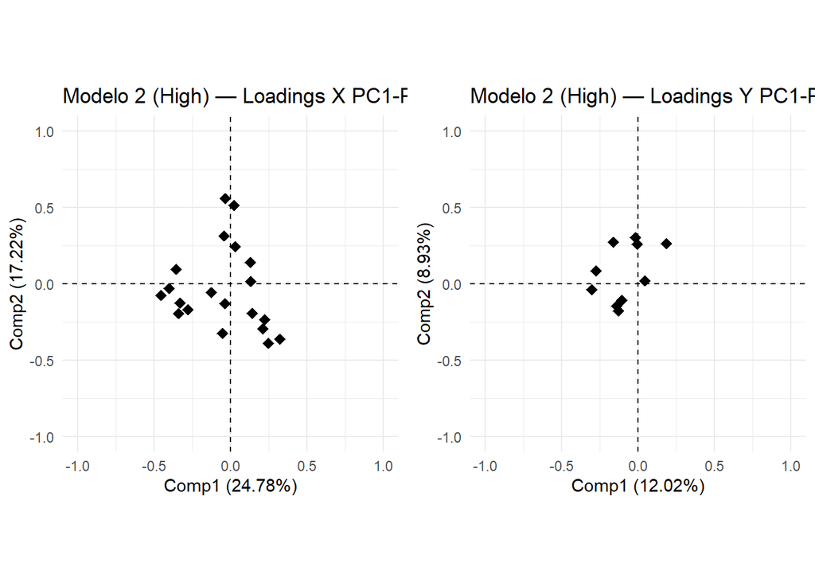

```r
p_loadX_high <- plsPlot(modelo2_high, type = "loadingsX", comp = 1:2, shape = "point", labels = FALSE, repel = TRUE) +
  ggtitle("Modelo 2 (High) — Loadings X PC1-PC2")
p_loadY_high <- plsPlot(modelo2_high, type = "loadingsY", comp = 1:2, shape = "point", labels = FALSE, repel = TRUE) +
  ggtitle("Modelo 2 (High) — Loadings Y PC1-PC2")
grid.arrange(p_loadX_high, p_loadY_high, ncol = 2)
```

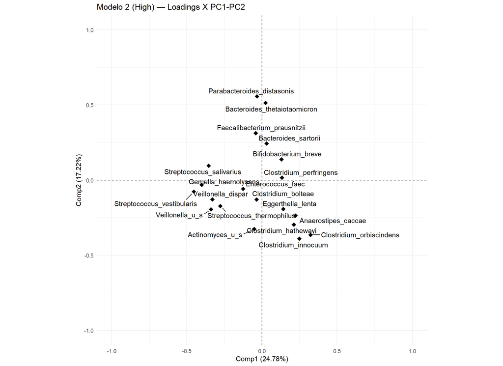

```r
plsPlot(modelo2_high, type = "loadingsX", comp = 1:2, shape = "point", labels = TRUE, repel = TRUE) +
  ggtitle("Modelo 2 (High) — Loadings X PC1-PC2")
```

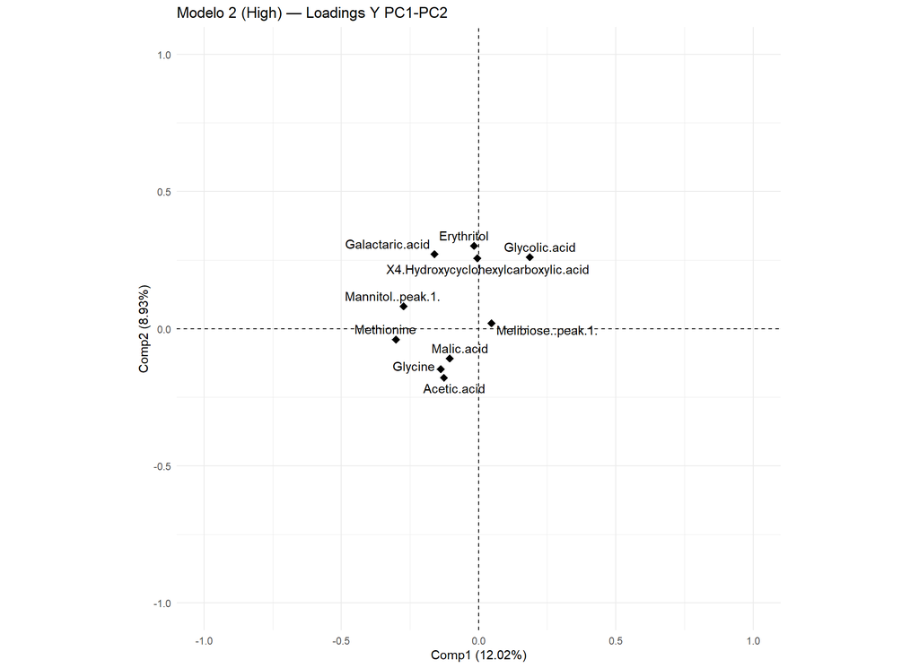

```r
plsPlot(modelo2_high, type = "loadingsY", comp = 1:2, shape = "point", labels = TRUE, repel = TRUE) +
  ggtitle("Modelo 2 (High) — Loadings Y PC1-PC2")
```

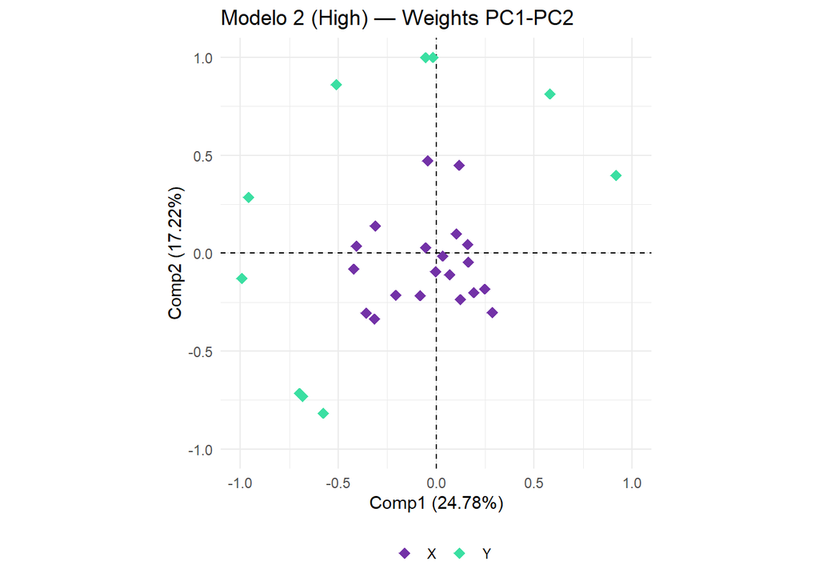

```r
plsPlot(modelo2_high, type = "weights", comp = 1:2, shape = "point",labels = FALSE, repel = TRUE) +
  ggtitle("Modelo 2 (High) — Weights PC1-PC2")
```

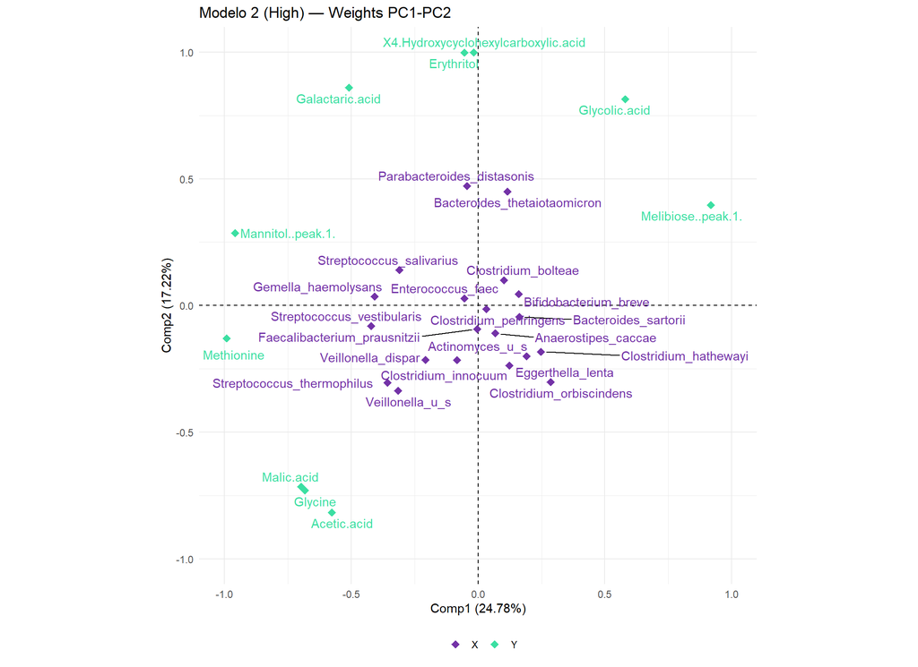

```r
plsPlot(modelo2_high, type = "weights", comp = 1:2, shape = "point",labels = TRUE, repel = TRUE) +
  ggtitle("Modelo 2 (High) — Weights PC1-PC2")
```

#### Standard

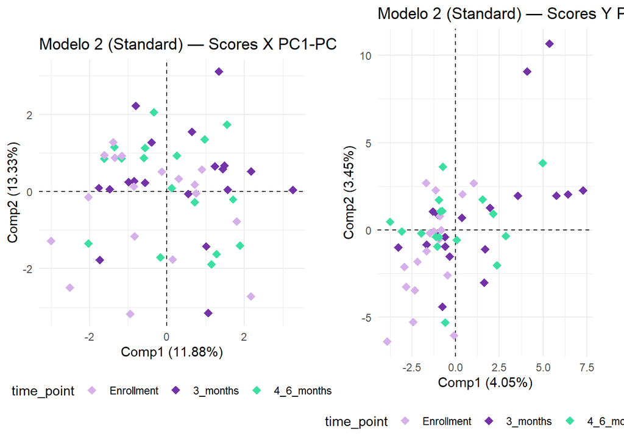

```r
covar_time_standard_model2 <- factor(species_standard_model2$time_point,
                                      levels = c("Enrollment", "3_months", "4_6_months"))

p1_standard <- plsPlot(modelo2_standard, type = "scoresX", comp = 1:2,
                        colBy = data.frame(time_point = covar_time_standard_model2),
                        labels = FALSE, ellipses = FALSE) +
  ggtitle("Modelo 2 (Standard) — Scores X PC1-PC2 por tiempo")

p2_standard <- plsPlot(modelo2_standard, type = "scoresY", comp = 1:2,
                        colBy = data.frame(time_point = covar_time_standard_model2),
                        labels = FALSE, ellipses = FALSE) +
  ggtitle("Modelo 2 (Standard) — Scores Y PC1-PC2 por tiempo")

grid.arrange(p1_standard, p2_standard, ncol = 2)
```

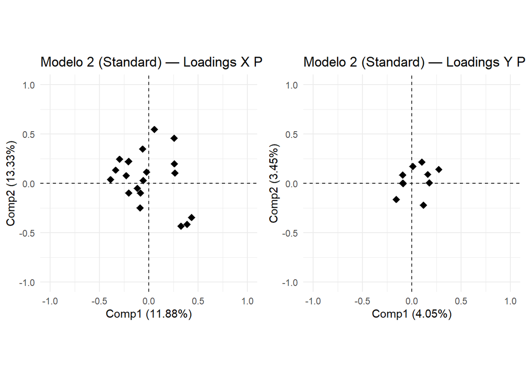

```r
p_loadX_standard <- plsPlot(modelo2_standard, type = "loadingsX", comp = 1:2, shape = "point", labels = FALSE, repel = TRUE) +
  ggtitle("Modelo 2 (Standard) — Loadings X PC1-PC2")
p_loadY_standard <- plsPlot(modelo2_standard, type = "loadingsY", comp = 1:2, shape = "point", labels = FALSE, repel = TRUE) +
  ggtitle("Modelo 2 (Standard) — Loadings Y PC1-PC2")
grid.arrange(p_loadX_standard, p_loadY_standard, ncol = 2)
```

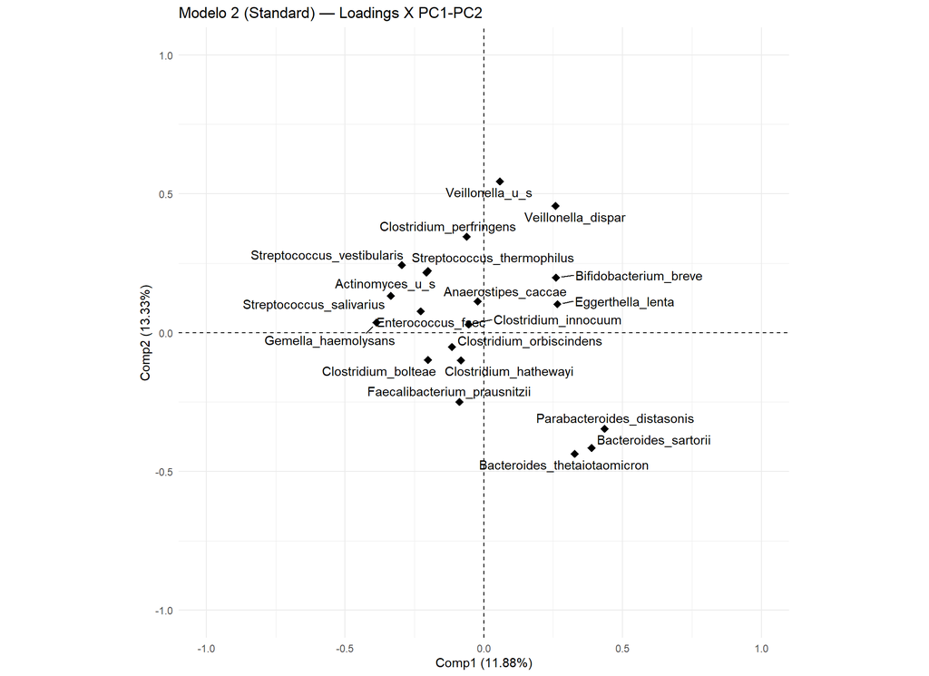

```r
plsPlot(modelo2_standard, type = "loadingsX", comp = 1:2, shape = "point", labels = TRUE, repel = TRUE) +
  ggtitle("Modelo 2 (Standard) — Loadings X PC1-PC2")
```

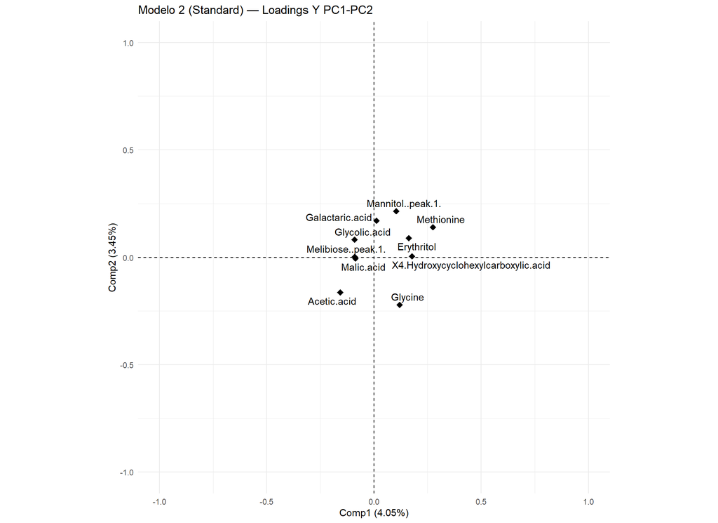

```r
plsPlot(modelo2_standard, type = "loadingsY", comp = 1:2, shape = "point", labels = TRUE, repel = TRUE) +
  ggtitle("Modelo 2 (Standard) — Loadings Y PC1-PC2")
```

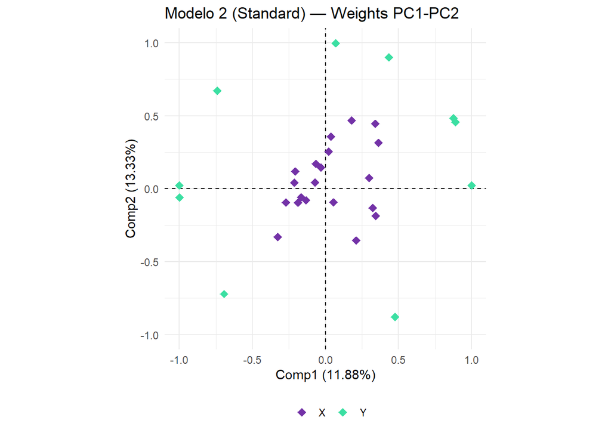

```r
plsPlot(modelo2_standard, type = "weights", comp = 1:2, labels = FALSE, shape = "point", repel = TRUE) +
  ggtitle("Modelo 2 (Standard) — Weights PC1-PC2")
```

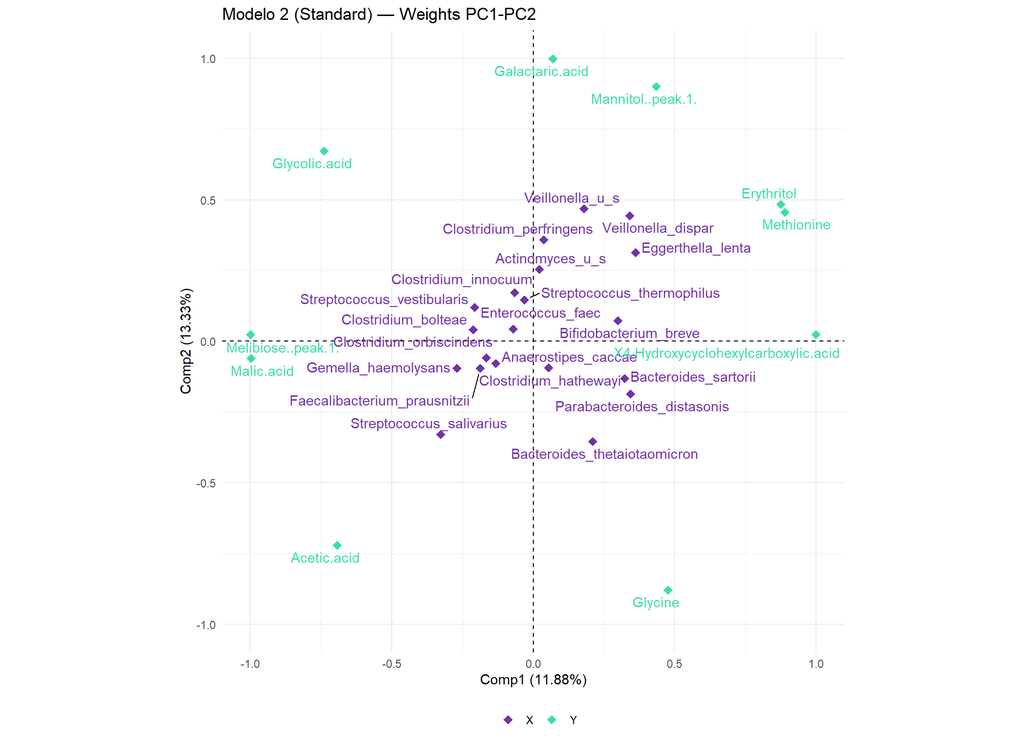

```r
plsPlot(modelo2_standard, type = "weights", comp = 1:2, labels = TRUE, shape = "point", repel = TRUE) +
  ggtitle("Modelo 2 (Standard) — Weights PC1-PC2")
```

#### Negative

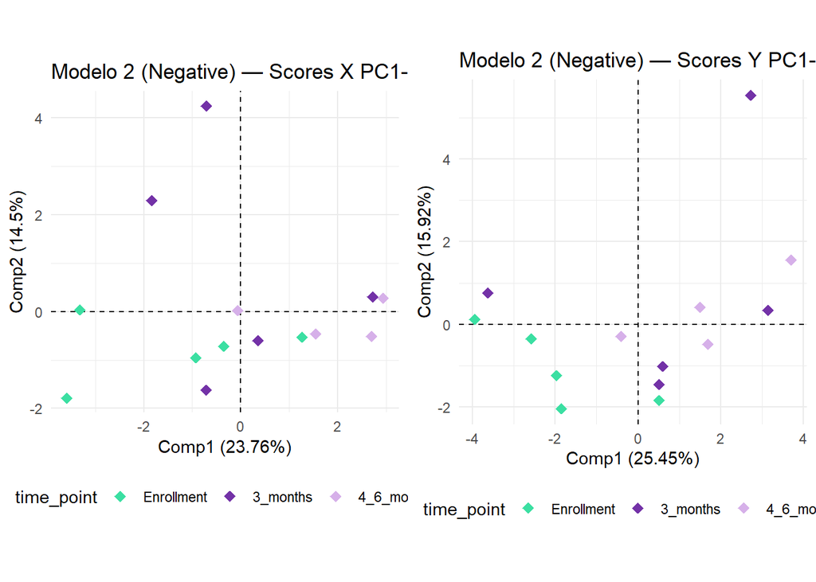

```r
covar_time_negative_model2 <- factor(species_negative_model2$time_point,
                                      levels = c("Enrollment", "3_months", "4_6_months"))

p1_negative <- plsPlot(modelo2_negative, type = "scoresX", comp = 1:2,
                        colBy = data.frame(time_point = covar_time_negative_model2),
                        labels = FALSE, ellipses = FALSE) +
  ggtitle("Modelo 2 (Negative) — Scores X PC1-PC2 por tiempo")

p2_negative <- plsPlot(modelo2_negative, type = "scoresY", comp = 1:2,
                        colBy = data.frame(time_point = covar_time_negative_model2),
                        labels = FALSE, ellipses = FALSE) +
  ggtitle("Modelo 2 (Negative) — Scores Y PC1-PC2 por tiempo")

grid.arrange(p1_negative, p2_negative, ncol = 2)
```

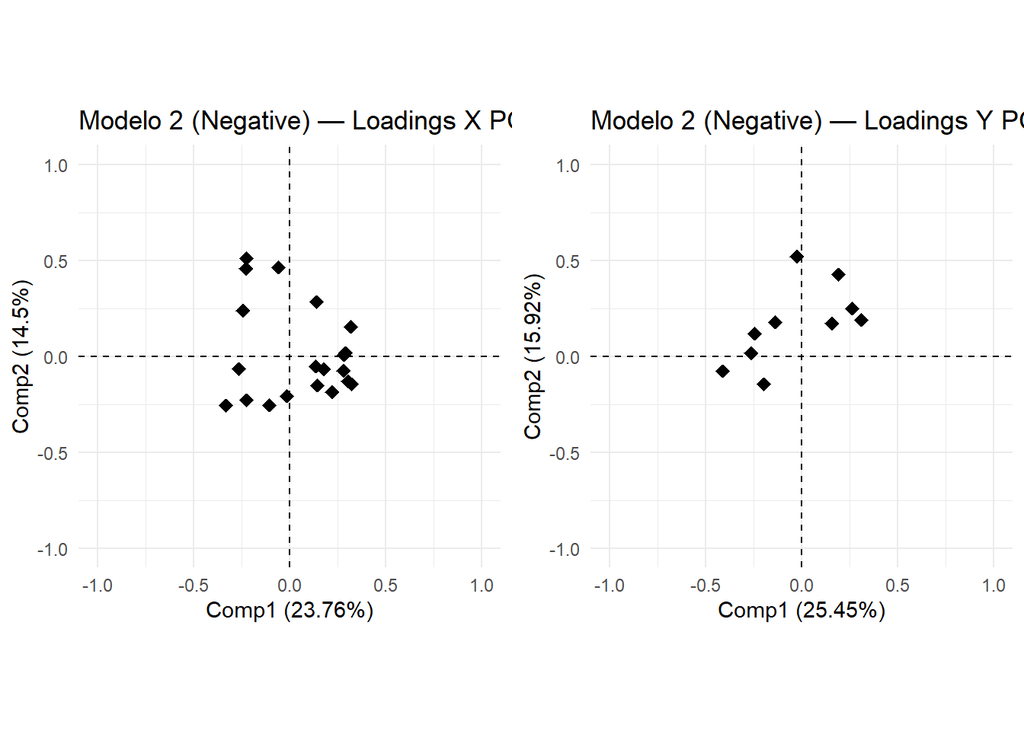

```r
p_loadX_negative <- plsPlot(modelo2_negative, type = "loadingsX", comp = 1:2, shape = "point", labels = FALSE, repel = TRUE) +
  ggtitle("Modelo 2 (Negative) — Loadings X PC1-PC2")
p_loadY_negative <- plsPlot(modelo2_negative, type = "loadingsY", comp = 1:2, shape = "point", labels = FALSE, repel = TRUE) +
  ggtitle("Modelo 2 (Negative) — Loadings Y PC1-PC2")
grid.arrange(p_loadX_negative, p_loadY_negative, ncol = 2)
```

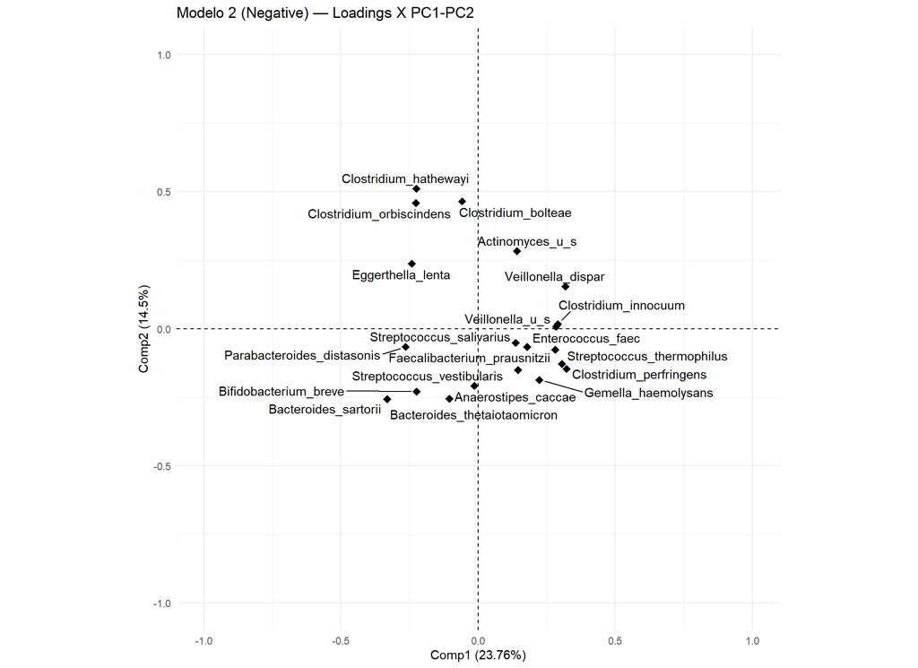

```r
plsPlot(modelo2_negative, type = "loadingsX", comp = 1:2, shape = "point", labels = TRUE, repel = TRUE) +
  ggtitle("Modelo 2 (Negative) — Loadings X PC1-PC2")
```

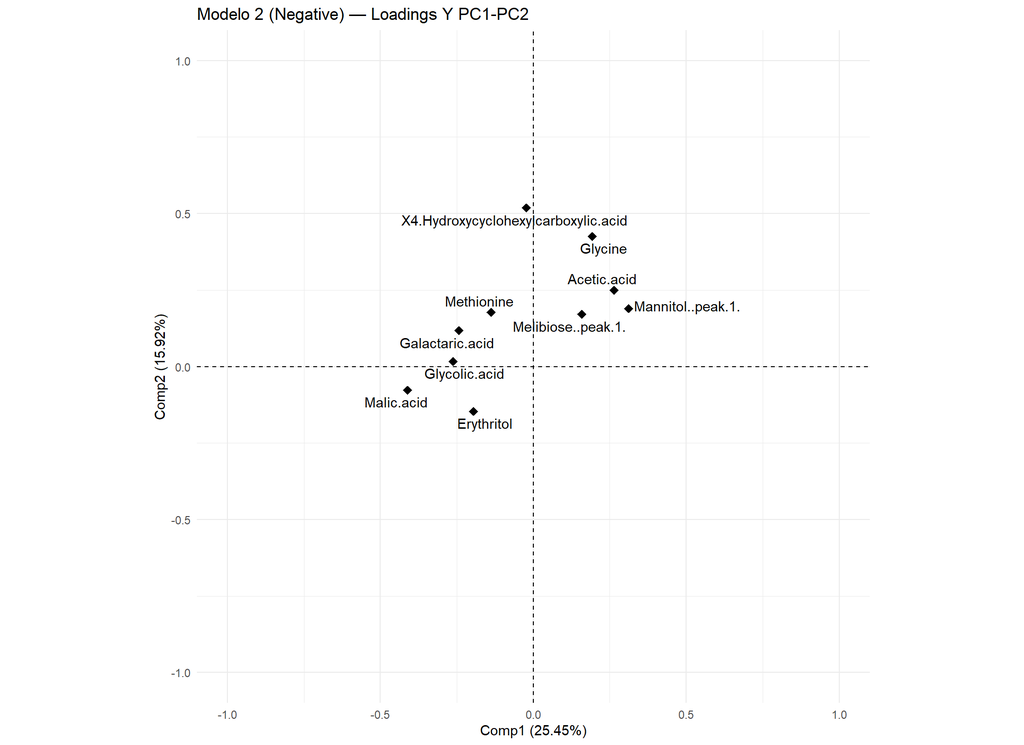

```r
plsPlot(modelo2_negative, type = "loadingsY", comp = 1:2, shape = "point", labels = TRUE, repel = TRUE) +
  ggtitle("Modelo 2 (Negative) — Loadings Y PC1-PC2")
```

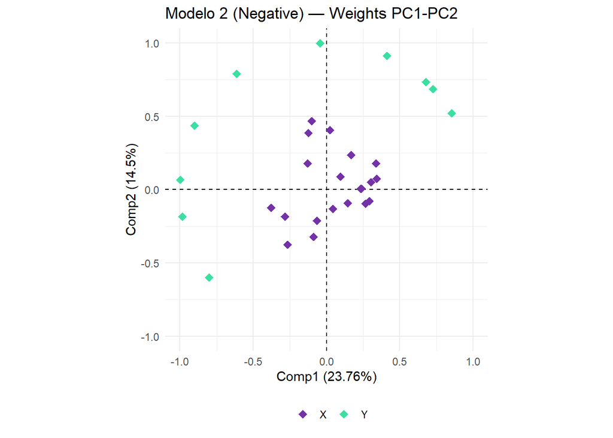

```r
plsPlot(modelo2_negative, type = "weights", comp = 1:2, labels = FALSE, shape = "point", repel = TRUE) +
  ggtitle("Modelo 2 (Negative) — Weights PC1-PC2")
```

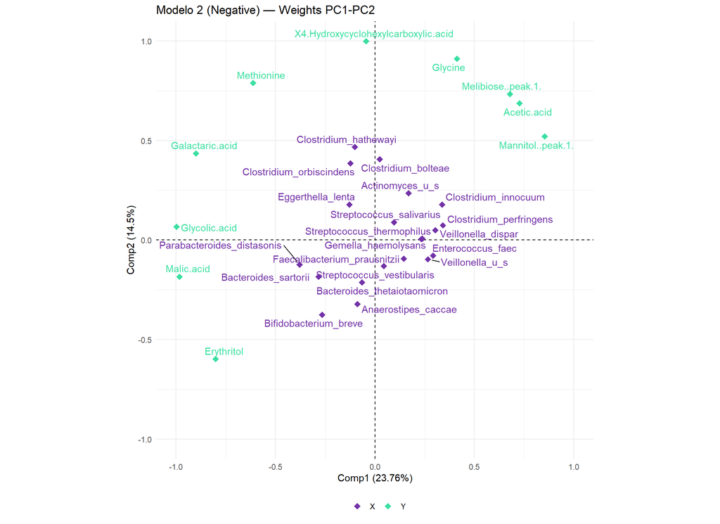

```r
plsPlot(modelo2_negative, type = "weights", comp = 1:2, labels = TRUE, shape = "point", repel = TRUE) +
  ggtitle("Modelo 2 (Negative) — Weights PC1-PC2")
```

### 2.5.4 Significación de relaciones bacteria-metabolito, por subgrupo

#### Ajuste (Jackknife / Permutación / VIP)

```r
set.seed(123)
jack_high <- plsVarSel(modelo2_high, type = "Jack", rep = 100, threshold = 0.05)
```

```r
perm_high <- plsVarSel(modelo2_high, type = "Perm", rep = 1000, threshold = 0.05)
```

```r
vip_high  <- plsVarSel(modelo2_high, type = "VIP")
```

```r
set.seed(123)
jack_standard <- plsVarSel(modelo2_standard, type = "Jack", rep = 100, threshold = 0.05)
```

```r
perm_standard <- plsVarSel(modelo2_standard, type = "Perm", rep = 1000, threshold = 0.05)
```

```r
vip_standard  <- plsVarSel(modelo2_standard, type = "VIP")
```

```r
set.seed(123)
jack_negative <- plsVarSel(modelo2_negative, type = "Jack", rep = 100, threshold = 0.05)
```

```r
perm_negative <- plsVarSel(modelo2_negative, type = "Perm", rep = 1000, threshold = 0.05)
```

```r
vip_negative  <- plsVarSel(modelo2_negative, type = "VIP")
```

#### Resumen de conteos por subgrupo

```r
cat("High     - Jack:", sum(sapply(jack_high, nrow) > 0), " Perm:", sum(sapply(perm_high, nrow) > 0), " VIP:", nrow(vip_high), "\n")
```

```
## High     - Jack: 0  Perm: 4  VIP: 9
```

```r
cat("Standard - Jack:", sum(sapply(jack_standard, nrow) > 0), " Perm:", sum(sapply(perm_standard, nrow) > 0), " VIP:", nrow(vip_standard), "\n")
```

```
## Standard - Jack: 0  Perm: 5  VIP: 10
```

```r
cat("Negative - Jack:", sum(sapply(jack_negative, nrow) > 0), " Perm:", sum(sapply(perm_negative, nrow) > 0), " VIP:", nrow(vip_negative), "\n")
```

```
## Negative - Jack: 0  Perm: 3  VIP: 11
```

#### Tabla de relaciones — High

```r
tabla_high_model2 <- perm_high[sapply(perm_high, nrow) > 0] %>%
  imap_dfr(~ tibble(
    metabolito = .y,
    bacteria   = rownames(.x),
    p_perm     = .x$pValPerm
  )) %>%
  mutate(en_VIP = bacteria %in% rownames(vip_high)) %>%
  mutate(coeficiente = modelo2_high$coefficients[cbind(bacteria, metabolito)]) %>%
  arrange(metabolito, p_perm)

tabla_standard_model2 <- perm_standard[sapply(perm_standard, nrow) > 0] %>%
  imap_dfr(~ tibble(
    metabolito = .y,
    bacteria   = rownames(.x),
    p_perm     = .x$pValPerm
  )) %>%
  mutate(en_VIP = bacteria %in% rownames(vip_standard)) %>%
  mutate(coeficiente = modelo2_standard$coefficients[cbind(bacteria, metabolito)]) %>%
  arrange(metabolito, p_perm)

tabla_negative_model2 <- perm_negative[sapply(perm_negative, nrow) > 0] %>%
  imap_dfr(~ tibble(
    metabolito = .y,
    bacteria   = rownames(.x),
    p_perm     = .x$pValPerm
  )) %>%
  mutate(en_VIP = bacteria %in% rownames(vip_negative)) %>%
  mutate(coeficiente = modelo2_negative$coefficients[cbind(bacteria, metabolito)]) %>%
  arrange(metabolito, p_perm)

tabla_high_model2
```

```
## # A tibble: 7 × 5
##   metabolito      bacteria                     p_perm en_VIP coeficiente
##   <chr>           <chr>                         <dbl> <lgl>        <dbl>
## 1 Erythritol      Parabacteroides_distasonis    0.038 TRUE         0.143
## 2 Galactaric.acid Clostridium_orbiscindens      0.042 TRUE        -0.128
## 3 Galactaric.acid Parabacteroides_distasonis    0.047 TRUE         0.135
## 4 Glycolic.acid   Bacteroides_thetaiotaomicron  0.02  TRUE         0.139
## 5 Glycolic.acid   Veillonella_u_s               0.021 TRUE        -0.147
## 6 Glycolic.acid   Streptococcus_thermophilus    0.033 TRUE        -0.146
## 7 Methionine      Streptococcus_vestibularis    0.037 TRUE         0.130
```

#### Tabla de relaciones — Standard

```r
tabla_standard_model2
```

```
## # A tibble: 8 × 5
##   metabolito                          bacteria         p_perm en_VIP coeficiente
##   <chr>                               <chr>             <dbl> <lgl>        <dbl>
## 1 Acetic.acid                         Streptococcus_s…  0.014 TRUE         0.202
## 2 Acetic.acid                         Eggerthella_len…  0.049 TRUE        -0.180
## 3 Galactaric.acid                     Streptococcus_s…  0.022 TRUE        -0.165
## 4 Glycine                             Streptococcus_s…  0.04  TRUE         0.168
## 5 Methionine                          Streptococcus_s…  0.001 TRUE        -0.251
## 6 Methionine                          Veillonella_dis…  0.022 TRUE         0.184
## 7 X4.Hydroxycyclohexylcarboxylic.acid Eggerthella_len…  0.045 TRUE         0.193
## 8 X4.Hydroxycyclohexylcarboxylic.acid Parabacteroides…  0.046 TRUE         0.179
```

#### Tabla de relaciones — Negative

```r
tabla_negative_model2
```

```
## # A tibble: 8 × 5
##   metabolito                          bacteria         p_perm en_VIP coeficiente
##   <chr>                               <chr>             <dbl> <lgl>        <dbl>
## 1 Glycine                             Clostridium_hat…  0.03  TRUE         0.179
## 2 Glycine                             Bifidobacterium…  0.045 TRUE        -0.211
## 3 Malic.acid                          Parabacteroides…  0.047 TRUE         0.165
## 4 Malic.acid                          Clostridium_inn…  0.048 TRUE        -0.153
## 5 X4.Hydroxycyclohexylcarboxylic.acid Clostridium_hat…  0.001 TRUE         0.245
## 6 X4.Hydroxycyclohexylcarboxylic.acid Clostridium_orb…  0.003 TRUE         0.203
## 7 X4.Hydroxycyclohexylcarboxylic.acid Clostridium_bol…  0.011 TRUE         0.210
## 8 X4.Hydroxycyclohexylcarboxylic.acid Bifidobacterium…  0.015 TRUE        -0.189
```

```r
write_csv(tabla_high_model2,     file.path(processed_dir, "relaciones_bacteria_metabolito_model2_high.csv"))
write_csv(tabla_standard_model2, file.path(processed_dir, "relaciones_bacteria_metabolito_model2_standard.csv"))
write_csv(tabla_negative_model2, file.path(processed_dir, "relaciones_bacteria_metabolito_model2_negative.csv"))
```

### 2.5.5 Comparación entre los tres subgrupos

```r
pares_high_model2     <- paste(tabla_high_model2$bacteria, tabla_high_model2$metabolito, sep = "__")
pares_standard_model2 <- paste(tabla_standard_model2$bacteria, tabla_standard_model2$metabolito, sep = "__")
pares_negative_model2 <- paste(tabla_negative_model2$bacteria, tabla_negative_model2$metabolito, sep = "__")

cat("--- High vs. Negative ---\n")
```

```
## --- High vs. Negative ---
```

```r
cat("Relaciones solo en High:     ", length(setdiff(pares_high_model2, pares_negative_model2)), "\n")
```

```
## Relaciones solo en High:      7
```

```r
cat("Relaciones solo en Negative: ", length(setdiff(pares_negative_model2, pares_high_model2)), "\n")
```

```
## Relaciones solo en Negative:  8
```

```r
cat("Relaciones en ambos:         ", length(intersect(pares_high_model2, pares_negative_model2)), "\n\n")
```

```
## Relaciones en ambos:          0
```

```r
cat("--- High vs. Standard ---\n")
```

```
## --- High vs. Standard ---
```

```r
cat("Relaciones solo en High:     ", length(setdiff(pares_high_model2, pares_standard_model2)), "\n")
```

```
## Relaciones solo en High:      7
```

```r
cat("Relaciones solo en Standard: ", length(setdiff(pares_standard_model2, pares_high_model2)), "\n")
```

```
## Relaciones solo en Standard:  8
```

```r
cat("Relaciones en ambos:         ", length(intersect(pares_high_model2, pares_standard_model2)), "\n\n")
```

```
## Relaciones en ambos:          0
```

```r
cat("--- Standard vs. Negative ---\n")
```

```
## --- Standard vs. Negative ---
```

```r
cat("Relaciones solo en Standard: ", length(setdiff(pares_standard_model2, pares_negative_model2)), "\n")
```

```
## Relaciones solo en Standard:  8
```

```r
cat("Relaciones solo en Negative: ", length(setdiff(pares_negative_model2, pares_standard_model2)), "\n")
```

```
## Relaciones solo en Negative:  8
```

```r
cat("Relaciones en ambos:         ", length(intersect(pares_standard_model2, pares_negative_model2)), "\n\n")
```

```
## Relaciones en ambos:          0
```

```r
cat("Bacterias en High:     ", paste(sort(unique(tabla_high_model2$bacteria)), collapse = ", "), "\n")
```

```
## Bacterias en High:      Bacteroides_thetaiotaomicron, Clostridium_orbiscindens, Parabacteroides_distasonis, Streptococcus_thermophilus, Streptococcus_vestibularis, Veillonella_u_s
```

```r
cat("Bacterias en Standard: ", paste(sort(unique(tabla_standard_model2$bacteria)), collapse = ", "), "\n")
```

```
## Bacterias en Standard:  Eggerthella_lenta, Parabacteroides_distasonis, Streptococcus_salivarius, Veillonella_dispar
```

```r
cat("Bacterias en Negative: ", paste(sort(unique(tabla_negative_model2$bacteria)), collapse = ", "), "\n")
```

```
## Bacterias en Negative:  Bifidobacterium_breve, Clostridium_bolteae, Clostridium_hathewayi, Clostridium_innocuum, Clostridium_orbiscindens, Parabacteroides_distasonis
```

```r
Reduce(intersect, list(pares_high_model2, pares_standard_model2, pares_negative_model2))
```

```
## character(0)
```

```r
intersect(pares_high_model2, pares_negative_model2)
```

```
## character(0)
```

```r
intersect(pares_high_model2, pares_standard_model2)
```

```
## character(0)
```

```r
intersect(pares_standard_model2, pares_negative_model2)
```

```
## character(0)
```